# Comprehensive Ecological and Fisheries Data Analysis with aquats

### 1.17.2 In-Vignette Data Generation

```r
set.seed(1515)
n_per_zone <- 8
lake_zones <- c("Littoral", "Pelagic", "Hypolimnetic")

phyto_list <- lapply(lake_zones, function(zn) {
  means <- switch(zn,
    "Littoral"     = c(Diatom_A = 35, Diatom_B = 24, Cyanob_A = 4,  Cyanob_B = 1,  Green_A = 18, Green_B = 12),
    "Pelagic"      = c(Diatom_A = 12, Diatom_B = 8,  Cyanob_A = 42, Cyanob_B = 30, Green_A = 25, Green_B = 18),
    "Hypolimnetic" = c(Diatom_A = 4,  Diatom_B = 2,  Cyanob_A = 2,  Cyanob_B = 0,  Green_A = 6,  Green_B = 4)
  )
  mat <- do.call(cbind, lapply(means, function(m) rpois(n_per_zone, lambda = m)))
  df <- as.data.frame(mat)
  df$Zone <- zn
  df
})

phyto_survey <- do.call(rbind, phyto_list)
rownames(phyto_survey) <- paste0("ST_", sprintf("%02d", seq_len(nrow(phyto_survey))))

# Organize grouping metadata column
phyto_survey <- phyto_survey[, c("Zone", setdiff(names(phyto_survey), "Zone"))]

head(phyto_survey[, 1:5], 5)
```

```
#>           Zone Diatom_A Diatom_B Cyanob_A Cyanob_B
#> ST_01 Littoral       29       24        7        3
#> ST_02 Littoral       33       16        3        0
#> ST_03 Littoral       40       14        1        1
#> ST_04 Littoral       40       30        1        3
#> ST_05 Littoral       34       29        4        5
```

### 1.17.3 Visualization Styles

The `cluster_dendrogram()` function generates vertical and horizontal dendrogram views with group-coded leaf tips.

#### 1.17.3.1 Style A: Vertical Tree Layout with Cluster Partitioning Line (Default)

Applies Hellinger pre-transformation with Bray-Curtis dissimilarity and UPGMA (`average`) clustering, displaying a threshold line at $k = 3$:

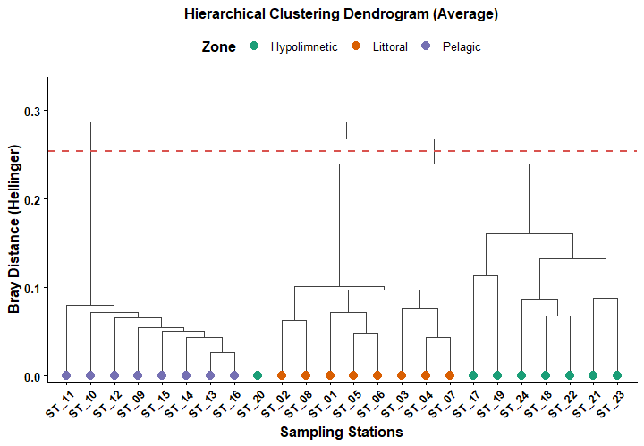

```r
res_dendro <- cluster_dendrogram(
  data           = phyto_survey,
  group_col      = "Zone",
  dist_method    = "bray",
  transform      = "hellinger",
  cluster_method = "average",
  k              = 3,
  palette        = "Dark2",
  orientation    = "vertical"
)

# Render publication tree
res_dendro$Plot
```

#### 1.17.3.2 Style B: Horizontal Tree Layout

Using `orientation = "horizontal"` flips the coordinate axes, making station labels easier to read when sample sizes are larger:

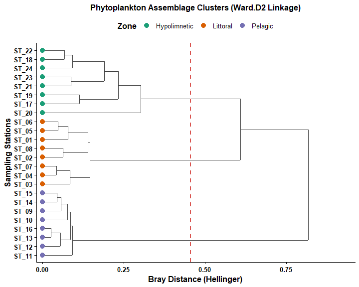

```r
res_dendro_horiz <- cluster_dendrogram(
  data           = phyto_survey,
  group_col      = "Zone",
  dist_method    = "bray",
  transform      = "hellinger",
  cluster_method = "ward.D2",
  k              = 3,
  palette        = "Dark2",
  orientation    = "horizontal",
  title          = "Phytoplankton Assemblage Clusters (Ward.D2 Linkage)"
)

res_dendro_horiz$Plot
```

### 1.17.4 Model Inspection and Numerical Summaries

The returned list provides the sample-to-cluster assignment table, dissimilarity matrix, and underlying `hclust` object:

```r
# 1. Sample Cluster Membership Assignments
head(res_dendro$Cluster_Assignments, 10)
```

```
#>    Sample     Zone   Cluster
#> 1   ST_01 Littoral Cluster_1
#> 2   ST_02 Littoral Cluster_1
#> 3   ST_03 Littoral Cluster_1
#> 4   ST_04 Littoral Cluster_1
#> 5   ST_05 Littoral Cluster_1
#> 6   ST_06 Littoral Cluster_1
#> 7   ST_07 Littoral Cluster_1
#> 8   ST_08 Littoral Cluster_1
#> 9   ST_09  Pelagic Cluster_2
#> 10  ST_10  Pelagic Cluster_2
```

```r
# 2. Inspect Agglomerative Cluster Merges
res_dendro$HClust_Object$merge[1:6, ]
```

```
#>      [,1] [,2]
#> [1,]  -13  -16
#> [2,]  -14    1
#> [3,]   -4   -7
#> [4,]   -5   -6
#> [5,]  -15    2
#> [6,]   -9    5
```

```r
# 3. Distance Matrix Preview (First 4 Samples)
as.matrix(res_dendro$Distance_Matrix)[1:4, 1:4]
```

```
#>            ST_01     ST_02      ST_03      ST_04
#> ST_01 0.00000000 0.1173526 0.11920702 0.06805391
#> ST_02 0.11735263 0.0000000 0.10490610 0.10833905
#> ST_03 0.11920702 0.1049061 0.00000000 0.08964695
#> ST_04 0.06805391 0.1083391 0.08964695 0.00000000
```

## 1.18 Correlation Heatmaps for Environmental & Morphometric Matrices

The `correlation_heatmap()` function generates publication-ready correlation heatmaps for multidimensional environmental, limnological, and fisheries datasets. In aquatic ecosystem monitoring, evaluating pairwise associations among water quality parameters (e.g., Temperature, Dissolved Oxygen, Nutrients, Turbidity) is an essential exploratory step before conducting constrained ordinations or regression modeling.

The function computes correlation coefficients across Pearson, Spearman, or Kendall formulations, extracts pairwise significance $p$-values, supports directional matrix views (`lower`, `upper`, or `full`), provides alternative tile geometries (`square` or `circle`), and dynamically adjusts annotation font contrast across diverging color palettes.

### 1.18.1 Conceptual Framework and Statistical Formulation

For two continuous variables $X$ and $Y$ observed across $n$ sampling stations:

#### 1.18.1.1 Pearson Product-Moment Correlation

Measures linear dependency between normally distributed continuous variables:

$$r_{xy} = \frac{\sum_{i=1}^n (x_i -
\bar{x})(y_i - \bar{y})}{\sqrt{\sum_{i=1}^n (x_i - \bar{x})^2
\sum_{i=1}^n (y_i - \bar{y})^2}}$$

The statistical significance of $r_{xy}$ is evaluated using a two-tailed Student’s $t$-distribution with $\nu = n - 2$ degrees of freedom:

$$t = r_{xy} \sqrt{\frac{n - 2}{1 -
r_{xy}^2}}$$

#### 1.18.1.2 Spearman Rank-Order Correlation

Measures monotonic relationships between non-normally distributed or ordinal parameters by computing Pearson’s coefficient on ranked values:

$$\rho = 1 - \frac{6 \sum_{i=1}^n
d_i^2}{n(n^2 - 1)}$$

where $d_i = \text{rank}(x_i) - \text{rank}(y_i)$.

Pairwise significance thresholds are mapped to standard compact asterisks: - $\text{ns}: p \ge 0.05$ - $*: p < 0.05$ - $**: p < 0.01$ - $***: p < 0.001$

### 1.18.2 In-Vignette Data Generation

We simulate a multi-parameter aquatic environmental survey evaluating seven correlated physico-chemical variables recorded across 50 limnological stations:

```r
set.seed(1616)
n_stations <- 50

temp_c   <- rnorm(n_stations, mean = 23.5, sd = 2.8)
do_mgl   <- 13.8 - (0.32 * temp_c) + rnorm(n_stations, 0, 0.4)
ph_val   <- 7.1 + (0.05 * temp_c) + rnorm(n_stations, 0, 0.25)
turb_ntu <- runif(n_stations, 4, 38)
secchi_m <- 2.8 - (0.055 * turb_ntu) + rnorm(n_stations, 0, 0.2)
tp_mgl   <- 0.04 + (0.006 * turb_ntu) + rnorm(n_stations, 0, 0.02)
tn_mgl   <- 0.85 + (12.5 * tp_mgl) + rnorm(n_stations, 0, 0.15)

limno_env <- data.frame(
  Temperature = temp_c,
  DO          = do_mgl,
  pH          = ph_val,
  Turbidity   = turb_ntu,
  Secchi      = secchi_m,
  Total_P     = tp_mgl,
  Total_N     = tn_mgl
)

head(limno_env, 6)
```

```
#>   Temperature       DO       pH Turbidity    Secchi    Total_P  Total_N
#> 1    22.19114 5.982808 8.407656  8.327564 2.3928749 0.09957881 1.912191
#> 2    26.59665 6.100091 8.240560 24.557620 1.2303458 0.15707745 2.792743
#> 3    25.11247 6.161079 8.381893 34.516946 0.6536182 0.24425880 3.752906
#> 4    22.64647 6.449037 8.274918  9.993436 2.0100879 0.11489375 2.498569
#> 5    23.06031 7.278349 8.215123 30.431676 1.0822492 0.19719694 3.357934
#> 6    30.20779 2.871502 8.630534  9.455666 2.2882730 0.09409752 2.190112
```

### 1.18.3 Visualization Styles

The `correlation_heatmap()` function provides tile-based and bubble-based visual styles.

#### 1.18.3.1 Style A: Lower-Triangle Square Heatmap with Coefficients & Asterisks (Default)

Displays the lower triangle with correlation values and significance stars, automatically adjusting text color for high-contrast visibility:

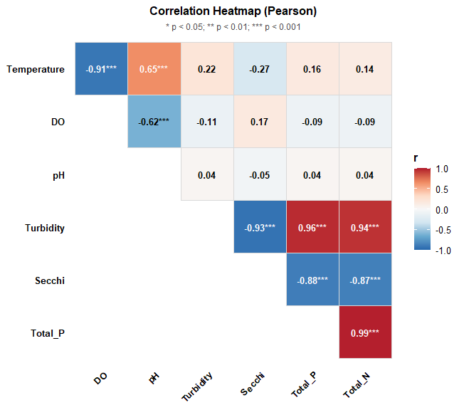

```r
res_cor_square <- correlation_heatmap(
  data          = limno_env,
  method        = "pearson",
  shape         = "square",
  view          = "lower",
  diag          = FALSE,
  label_type    = "both",
  color_palette = "RdBu"
)

# Render lower-triangle heatmap
res_cor_square$Plot
```

#### 1.18.3.2 Style B: Circle Bubble Heatmap with Significance Asterisks

Uses circle markers where bubble diameter corresponds to the absolute correlation magnitude ($\vert{}r\vert{}$) and color corresponds to directional correlation sign:

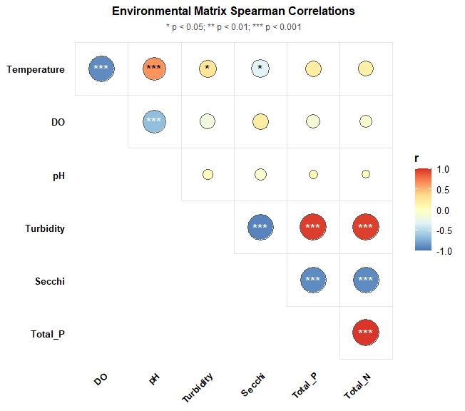

```r
res_cor_circle <- correlation_heatmap(
  data          = limno_env,
  method        = "spearman",
  shape         = "circle",
  view          = "lower",
  diag          = FALSE,
  label_type    = "stars",
  color_palette = "RdYlBu",
  title         = "Environmental Matrix Spearman Correlations"
)

res_cor_circle$Plot
```

### 1.18.4 Model Inspection and Numerical Summaries

The returned list provides the symmetric correlation coefficient matrix, exact $p$-values, and a tidy summary data frame:

```r
# 1. Pearson Correlation Matrix Preview
round(res_cor_square$Correlation_Matrix[1:4, 1:4], 3)
```

```
#>             Temperature     DO     pH Turbidity
#> Temperature       1.000 -0.915  0.652     0.218
#> DO               -0.915  1.000 -0.618    -0.110
#> pH                0.652 -0.618  1.000     0.036
#> Turbidity         0.218 -0.110  0.036     1.000
```

```r
# 2. Exact P-Value Matrix Preview
signif(res_cor_square$P_Value_Matrix[1:4, 1:4], 3)
```

```
#>             Temperature       DO       pH Turbidity
#> Temperature    0.00e+00 1.67e-20 2.99e-07     0.129
#> DO             1.67e-20 0.00e+00 1.71e-06     0.446
#> pH             2.99e-07 1.71e-06 0.00e+00     0.802
#> Turbidity      1.29e-01 4.46e-01 8.02e-01     0.000
```

```r
# 3. Tidy Pairwise Summary Table
head(res_cor_square$Summary_Table, 8)
```

```
#>       Var1        Var2 Correlation      P_Value Significance
#> 4       DO Temperature -0.91457645 1.674026e-20          ***
#> 8       pH          DO -0.61829870 1.712181e-06          ***
#> 11      pH Temperature  0.65150701 2.991092e-07          ***
#> 15  Secchi          DO  0.16852240 2.420479e-01           ns
#> 16  Secchi          pH -0.05415836 7.087424e-01           ns
#> 18  Secchi Temperature -0.27450426 5.370824e-02           ns
#> 21  Secchi   Turbidity -0.93266093 6.826376e-23          ***
#> 29 Total_N          DO -0.08583431 5.533923e-01           ns
```

## 1.19 Integrated Environmental Correlation and Mantel Network Analysis

The `mantel_heatmap_analysis()` function models and visualizes the coupling between abiotic environmental gradients and biological community structures. In aquatic ecology, researchers often analyze pairwise physico-chemical parameters alongside multivariate dissimilarity matrices across multiple trophic levels (e.g., Phytoplankton, Zooplankton, Benthos, Fish).

This function integrates these two workflows into a single display: 1. A pairwise environmental correlation matrix (Pearson or Spearman) rendered as a lower-triangular heatmap. 2. Community-wide Mantel tests connecting biological community nodes to corresponding environmental parameters using curved or straight linkage vectors.

Linkage attributes convey statistical properties: line thickness indicates the magnitude of the Mantel correlation coefficient ($r$), while color and line style denote permutation-derived significance thresholds ($p < 0.01$, $p < 0.05$, $p \ge 0.05$).

### 1.19.1 Conceptual Framework and Statistical Formulation

The analytical framework combines pairwise variable correlation with matrix permutation testing.

#### 1.19.1.1 Mantel Matrix Correlation

Let $\mathbf{D}_M$ represent the ecological dissimilarity matrix (e.g., Bray-Curtis) among $n$ sampling stations for a biological community:

$$d_{ij}^{(M)} = \frac{\sum_{k=1}^p
|y_{ik} - y_{jk}|}{\sum_{k=1}^p (y_{ik} + y_{jk})}$$

Let $\mathbf{D}_E$ denote the standardized Euclidean distance matrix computed across one or more environmental variables between the same sampling stations:

$$d_{ij}^{(E)} = \sqrt{\sum_{m=1}^q
(z_{im} - z_{jm})^2}$$

The Mantel test computes the Pearson correlation coefficient between the lower triangular elements ($j < i$) of the two unfolded distance matrices:

$$r_M = \frac{\sum_{i > j}
(d_{ij}^{(M)} - \bar{d}_M)(d_{ij}^{(E)} - \bar{d}_E)}{\sqrt{\sum_{i >
j} (d_{ij}^{(M)} - \bar{d}_M)^2 \sum_{i > j} (d_{ij}^{(E)} -
\bar{d}_E)^2}}$$

where $r_M \in [-1, 1]$.

#### 1.19.1.2 Permutation Significance Testing

Because elements within a distance matrix are not mutually independent, standard parametric tests for correlation significance are invalid. Instead, significance is assessed through Monte Carlo permutation of the rows and columns of one distance matrix (e.g., $\mathbf{D}_M$) while holding the second ($\mathbf{D}_E$) fixed:

$$p = \frac{\sum_{\pi=1}^B
\mathbb{I}(r_M^{(\pi)} \ge r_M^{\text{obs}}) + 1}{B + 1}$$

where $B$ is the number of random permutations (default: 999).

### 1.19.2 In-Vignette Data Generation

We simulate a limnological survey across 35 sampling stations containing six continuous environmental variables (Water Temperature, Dissolved Oxygen, pH, Turbidity, Total Phosphorus, Total Nitrogen) paired with two biological trophic communities: Phytoplankton (6 taxa) and Zooplankton (5 taxa):

```r
set.seed(1717)
n_stations <- 35

# 1. Environmental Gradients
temp_c   <- rnorm(n_stations, mean = 24.0, sd = 2.5)
do_mgl   <- 13.5 - (0.30 * temp_c) + rnorm(n_stations, 0, 0.4)
ph_val   <- 7.2 + (0.04 * temp_c) + rnorm(n_stations, 0, 0.2)
turb_ntu <- runif(n_stations, 5, 40)
tp_mgl   <- 0.03 + (0.007 * turb_ntu) + rnorm(n_stations, 0, 0.015)
tn_mgl   <- 0.70 + (14.0 * tp_mgl) + rnorm(n_stations, 0, 0.12)

env_matrix <- data.frame(
  Temp     = temp_c,
  DO       = do_mgl,
  pH       = ph_val,
  Turb     = turb_ntu,
  Total_P  = tp_mgl,
  Total_N  = tn_mgl
)

# 2. Phytoplankton Community Counts (sensitive to nutrients and turbidity)
phyto_mat <- data.frame(
  Cyanob_1  = rpois(n_stations, lambda = pmax(1, round(5 + 80 * tp_mgl))),
  Cyanob_2  = rpois(n_stations, lambda = pmax(1, round(3 + 60 * tp_mgl))),
  Diatom_1  = rpois(n_stations, lambda = pmax(1, round(28 - 0.4 * turb_ntu))),
  Diatom_2  = rpois(n_stations, lambda = pmax(1, round(20 - 0.3 * turb_ntu))),
  Chloroph_1 = rpois(n_stations, lambda = pmax(1, round(12 + 2.5 * ph_val))),
  Chloroph_2 = rpois(n_stations, lambda = pmax(1, round(10 + 1.8 * ph_val)))
)

# 3. Zooplankton Community Counts (sensitive to temperature and dissolved oxygen)
zoo_mat <- data.frame(
  Cladocera_1 = rpois(n_stations, lambda = pmax(1, round(2 + 2.2 * do_mgl))),
  Cladocera_2 = rpois(n_stations, lambda = pmax(1, round(4 + 1.8 * do_mgl))),
  Copepod_1   = rpois(n_stations, lambda = pmax(1, round(8 + 0.8 * temp_c))),
  Copepod_2   = rpois(n_stations, lambda = pmax(1, round(6 + 0.6 * temp_c))),
  Rotifer_1   = rpois(n_stations, lambda = pmax(1, round(15 + 0.3 * turb_ntu)))
)

# Bundle biological communities into a named list
aquatic_trophic_comms <- list(
  "Phytoplankton" = phyto_mat,
  "Zooplankton"   = zoo_mat
)

head(env_matrix, 4)
```

```
#>       Temp       DO       pH      Turb    Total_P  Total_N
#> 1 20.36277 7.331757 7.902365  7.094070 0.07979408 2.036248
#> 2 19.72894 7.526729 8.056922 27.895527 0.20880550 3.590681
#> 3 29.25114 3.755476 8.352574 10.632814 0.09551539 1.887045
#> 4 21.42924 7.085186 8.155138  6.198184 0.08728681 2.002546
```

### 1.19.3 Visualization Styles

The `mantel_heatmap_analysis()` function provides both an integrated network linkage diagram and a side-by-side barplot comparison.

#### 1.19.3.1 Style A: Curved Linkage Network Diagram (Default)

Projects environmental correlations as lower-triangular tiles while connecting community nodes to environmental anchors with curved vectors:

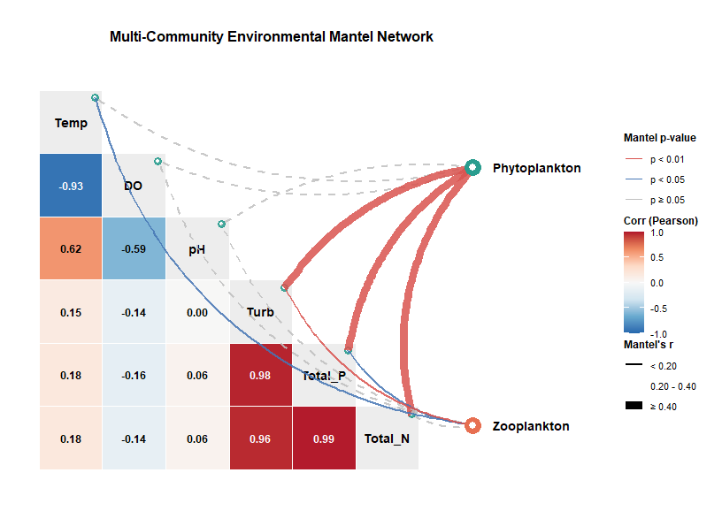

```r
res_mantel_net <- mantel_heatmap_analysis(
  comm_data        = aquatic_trophic_comms,
  env_data         = env_matrix,
  plot_type        = "network",
  line_style       = "curve",
  method           = "pearson",
  spec_dist        = "bray",
  transform        = "hellinger",
  only_significant = FALSE,
  line_color_by    = "significance",
  permutations     = 999,
  seed             = 42,
  show_cor_text    = TRUE,
  color_palette    = "RdBu"
)

# Render publication network plot
res_mantel_net$Plot
```

#### 1.19.3.2 Style B: Side-by-Side Correlation Heatmap and Mantel Bars

Displays the full environmental correlation matrix alongside horizontal bars showing Mantel $r$ effect sizes faceted across trophic communities:

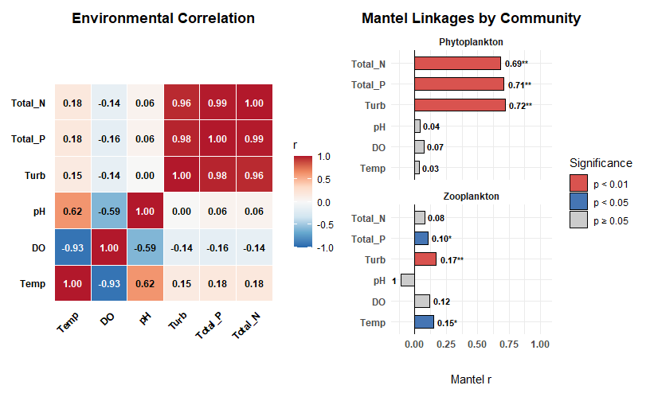

```r
res_mantel_bars <- mantel_heatmap_analysis(
  comm_data     = aquatic_trophic_comms,
  env_data      = env_matrix,
  plot_type     = "bars",
  method        = "pearson",
  spec_dist     = "bray",
  transform     = "hellinger",
  permutations  = 999,
  seed          = 42,
  color_palette = "RdBu"
)

res_mantel_bars$Plot
```

### 1.19.4 Model Inspection and Numerical Summaries

The returned list provides the pairwise environmental correlation matrix and a tidy data frame of community-specific Mantel statistics:

```r
# 1. Environmental Correlation Matrix (First 4 Variables)
round(res_mantel_net$Correlation_Matrix[1:4, 1:4], 3)
```

```
#>        Temp     DO     pH   Turb
#> Temp  1.000 -0.926  0.623  0.151
#> DO   -0.926  1.000 -0.593 -0.145
#> pH    0.623 -0.593  1.000  0.004
#> Turb  0.151 -0.145  0.004  1.000
```

```r
# 2. Tidy Mantel Test Statistics and Permutation P-Values
head(res_mantel_net$Mantel_Results, 8)
```

```
#>       Community Variable Mantel_r p_value Significance Mantel_R_Tier Line_Type
#> 1 Phytoplankton     Temp    0.032   0.303     p ≥ 0.05        < 0.20    dashed
#> 2 Phytoplankton       DO    0.074   0.177     p ≥ 0.05        < 0.20    dashed
#> 3 Phytoplankton       pH    0.043   0.282     p ≥ 0.05        < 0.20    dashed
#> 4 Phytoplankton     Turb    0.718   0.001     p < 0.01        ≥ 0.40     solid
#> 5 Phytoplankton  Total_P    0.709   0.001     p < 0.01        ≥ 0.40     solid
#> 6 Phytoplankton  Total_N    0.686   0.001     p < 0.01        ≥ 0.40     solid
#> 7   Zooplankton     Temp    0.148   0.045     p < 0.05        < 0.20     solid
#> 8   Zooplankton       DO    0.120   0.120     p ≥ 0.05        < 0.20    dashed
```

## 1.20 Ecological Alpha Diversity Indices & Comparative Testing

The `calc_diversity()` and `plot_diversity()` functions provide an integrated quantitative suite for estimating, testing, and visualizing community alpha diversity patterns in fisheries and aquatic ecology. Understanding local species richness, compositional dominance, and structural evenness is foundational for assessing habitat degradation, monitoring marine protected areas (MPAs), and comparing stocking strategies across culture environments.

The package calculates seven primary ecological metrics simultaneously: 1. Total Abundance ($N$): Overall individual organism counts. 2. Species Richness ($S$): Total count of unique taxa observed. 3. Shannon-Wiener Index ($H'$): Information-theoretic entropy capturing both richness and proportional abundance. 4. Gini-Simpson Index ($1 - D$): The probability that two randomly sampled individuals belong to different species. 5. Margalef’s Richness ($d$): Species richness normalized relative to the natural logarithm of sample size. 6. Menhinick’s Index ($D_{mn}$): Species richness adjusted relative to the square root of total abundance. 7. Pielou’s Evenness ($J'$): The ratio of observed Shannon diversity relative to maximum possible diversity.

The visualization function `plot_diversity()` pairs these indices with parametric (One-Way / Two-Way Factorial ANOVA) or non-parametric (Kruskal-Wallis) omnibus tests, calculates 1,000-iteration bootstrap confidence intervals, and formats publication-ready boxplots with raw observation overlays.

### 1.20.1 Conceptual Framework and Mathematical Formulation

Let a community sample contain $S$ observed species and total organism abundance $N = \sum_{i=1}^S n_i$, where $n_i$ represents the count of the $i$-th taxon. The relative abundance (proportion) of species $i$ is $p_i = n_i / N$.

#### 1.20.1.1 Shannon-Wiener Diversity Index ($H'$)

Derived from communication theory, $H'$ measures the uncertainty in predicting the species identity of a randomly sampled individual:

$$H' = -\sum_{i=1}^S p_i
\ln(p_i)$$

Values typically range between $1.5$ and $3.5$ in natural aquatic systems, with higher values reflecting richer and more equitable communities.

#### 1.20.1.2 Gini-Simpson Index ($1 - D$)

Simpson’s index of dominance measures the probability that two randomly selected individuals belong to the same species: $D = \sum_{i=1}^S p_i^2$. The complementary Gini-Simpson diversity metric is:

$$1 - D = 1 - \sum_{i=1}^S
p_i^2$$

This metric ranges from $0$ (monospecific culture) to $1.0$ (infinite community of equally abundant species).

#### 1.20.1.3 Species Richness Normalizations

Because raw observed richness ($S$) increases monotonically with sampling effort ($N$), Margalef ($d$) and Menhinick ($D_{mn}$) normalize richness across sample size discrepancies:

$$d = \frac{S - 1}{\ln(N)} \quad (N >
1)$$

$$D_{mn} = \frac{S}{\sqrt{N}} \quad (N
> 0)$$

#### 1.20.1.4 Pielou’s Equitability Index ($J'$)

Measures how close the observed distribution of abundances is to maximum theoretical evenness ($H'_{\max} = \ln(S)$):

$$J' = \frac{H'}{\ln(S)} \quad (S
> 1)$$

where $J' \in [0, 1]$. Values approaching $1.0$ indicate equal abundances across taxa, whereas lower values denote heavy dominance by one or two species.

### 1.20.2 In-Vignette Data Generation

We simulate a riverine fish biomonitoring survey assessing the abundances of 10 freshwater species across 36 sampling reaches categorized by River Zone (`Headwater`, `Mid-River`, `Lowland`) and Sampling Season (`Dry Season`, `Wet Season`):

```r
set.seed(1818)
n_reps <- 6

zones <- c("Headwater", "Mid-River", "Lowland")
seasons <- c("Dry Season", "Wet Season")

design <- expand.grid(Zone = zones, Season = seasons)

comm_runs <- lapply(seq_len(nrow(design)), function(idx) {
  zn <- as.character(design$Zone[idx])
  sn <- as.character(design$Season[idx])

  # Base abundance profiles
  means <- switch(zn,
    "Headwater" = c(Sp1 = 45, Sp2 = 38, Sp3 = 12, Sp4 = 2,  Sp5 = 0,  Sp6 = 0,  Sp7 = 0,  Sp8 = 0,  Sp9 = 0,  Sp10 = 0),
    "Mid-River" = c(Sp1 = 18, Sp2 = 22, Sp3 = 25, Sp4 = 16, Sp5 = 14, Sp6 = 8,  Sp7 = 4,  Sp8 = 1,  Sp9 = 0,  Sp10 = 0),
    "Lowland"   = c(Sp1 = 6,  Sp2 = 8,  Sp3 = 12, Sp4 = 24, Sp5 = 28, Sp6 = 32, Sp7 = 18, Sp8 = 15, Sp9 = 10, Sp10 = 6)
  )

  if (sn == "Wet Season") {
    means <- round(means * 1.35 + 2) # Seasonal flood pulse enhancement
  }

  mat <- do.call(cbind, lapply(means, function(m) rpois(n_reps, lambda = m)))
  df <- as.data.frame(mat)
  df$Zone <- zn
  df$Season <- sn
  df
})

fish_comm_data <- do.call(rbind, comm_runs)
# Organize grouping metadata columns at the front
fish_comm_data <- fish_comm_data[, c("Zone", "Season", paste0("Sp", 1:10))]

head(fish_comm_data[, 1:7], 6)
```

```
#>        Zone     Season Sp1 Sp2 Sp3 Sp4 Sp5
#> 1 Headwater Dry Season  38  39  16   0   0
#> 2 Headwater Dry Season  49  38   7   3   0
#> 3 Headwater Dry Season  49  47  14   2   0
#> 4 Headwater Dry Season  46  41  11   1   0
#> 5 Headwater Dry Season  56  47  17   4   0
#> 6 Headwater Dry Season  33  23   9   3   0
```

### 1.20.3 Index Calculation and Data Summary

First, calculate the complete alpha diversity table across all sampling stations using `calc_diversity()`:

```r
alpha_table <- calc_diversity(
  data      = fish_comm_data,
  group_col = c("Zone", "Season")
)

# Display sample output with computed diversity indices
head(alpha_table, 6)
```

```
#>   Sample      Zone     Season Abundance Richness Shannon Simpson Margalef
#> 1      1 Headwater Dry Season        93        3   1.033   0.628    0.441
#> 2      2 Headwater Dry Season        97        4   1.009   0.585    0.656
#> 3      3 Headwater Dry Season       112        4   1.058   0.617    0.636
#> 4      4 Headwater Dry Season        99        4   1.012   0.600    0.653
#> 5      5 Headwater Dry Season       124        4   1.110   0.633    0.622
#> 6      6 Headwater Dry Season        68        4   1.123   0.631    0.711
#>   Menhinick Pielou
#> 1     0.311  0.940
#> 2     0.406  0.728
#> 3     0.378  0.763
#> 4     0.402  0.730
#> 5     0.359  0.801
#> 6     0.485  0.810
```

### 1.20.4 Visualization Styles

`plot_diversity()` generates single-factor and two-factor (factorial) comparative displays.

#### 1.20.4.1 Style A: Single-Factor Diversity Comparison with Kruskal-Wallis Test (Default)

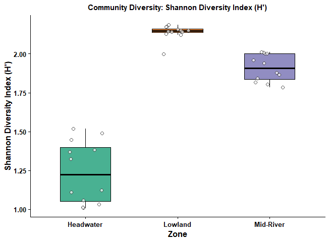

```r
res_div_single <- plot_diversity(
  data          = fish_comm_data,
  group_col     = "Zone",
  index         = "shannon",
  test          = "kruskal",
  color_palette = "Dark2",
  permutations  = 1000
)

# Render single-factor diversity plot
res_div_single$Plot
```

#### 1.20.4.2 Style B: Two-Factor Factorial Interaction Boxplot with Two-Way ANOVA

Evaluates how Pielou’s Evenness ($J'$) responds across the interaction of Zone and Season using dodged boxplots and parametric Two-Way ANOVA:

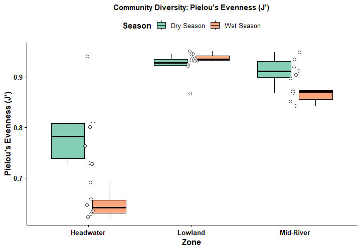

```r
res_div_factorial <- plot_diversity(
  data          = fish_comm_data,
  group_col     = c("Zone", "Season"),
  index         = "pielou",
  test          = "anova",
  color_palette = "Set2",
  permutations  = 1000
)

# Render factorial diversity plot
res_div_factorial$Plot
```

### 1.20.5 Model Inspection and Numerical Summaries

The returned list provides the underlying tidy diversity dataframe, bootstrap 95% confidence intervals, and hypothesis test output:

```r
# 1. Omnibus Hypothesis Test Result (Kruskal-Wallis / ANOVA)
res_div_single$Test_Result
```

```
#>
#>  Kruskal-Wallis rank sum test
#>
#> data:  Metric_Value by Zone
#> Kruskal-Wallis chi-squared = 30.298, df = 2, p-value = 2.635e-07
```

```r
# 2. Bootstrap Summary Statistics (Means, 95% Lower and Upper Confidence Limits)
res_div_single$Group_Summary
```

```
#>       Group   Index  N  Mean   LCI   UCI
#> 1 Headwater Shannon 12 1.242 1.139 1.348
#> 2   Lowland Shannon 12 2.138 2.108 2.160
#> 3 Mid-River Shannon 12 1.911 1.862 1.955
```

```r
# 3. Two-Way ANOVA Factorial Summary Table
res_div_factorial$Test_Result
```

```
#>             Df  Sum Sq Mean Sq F value   Pr(>F)
#> Zone         2 0.29240 0.14620   97.19 7.80e-14 ***
#> Season       1 0.02987 0.02987   19.86 0.000108 ***
#> Zone:Season  2 0.04179 0.02090   13.89 5.37e-05 ***
#> Residuals   30 0.04513 0.00150
#> ---
#> Signif. codes:  0 '***' 0.001 '**' 0.01 '*' 0.05 '.' 0.1 ' ' 1
```

## 1.21 Species Accumulation Curves & Sampling Effort Evaluation

The `specaccum_plot()` function constructs and visualizes species accumulation curves (collector’s curves) to evaluate inventory completeness, sampling sufficiency, and species richness scaling in aquatic biomonitoring and fisheries assessments. When conducting community surveys (e.g., river electrofishing, benthic grab surveys, plankton trawls), raw observed species counts are constrained by sampling intensity.

Species accumulation curves model the expected rate at which new species are recorded as additional sampling units or hauls are aggregated. Asymptotic leveling of the curve signifies sampling saturation—demonstrating that the sampling protocol has captured the majority of common and rare taxa within the target habitat.

The function computes curves using `vegan::specaccum`, accommodates multiple analytical accumulation methods (e.g., `exact` analytical solution, `coleman` rarefaction, or random permutations), calculates 95% confidence intervals, and generates publication-grade visualizations for single pooled inventories or comparative multi-habitat groupings (`by_group = TRUE`).

### 1.21.1 Conceptual Framework and Mathematical Formulation

Let a community dataset comprise $N$ total sampling units and $S_{\text{obs}}$ total observed species across the pooled inventory.

#### 1.21.1.1 The Exact Analytical Expectation (Mao Tau Formulation)

Rather than relying solely on empirical randomizations, `method = "exact"` calculates the expected species richness $\bar{S}_n$ for any sub-sample of $n$ sampling units ($1 \le n \le N$) using combinatorial probability:

$$\bar{S}_n = S_{\text{obs}} -
\sum_{i=1}^{S_{\text{obs}}} \frac{\binom{N -
f_i}{n}}{\binom{N}{n}}$$

where $f_i$ denotes the incidence frequency (number of sampling units containing species $i$). The combinatorial term represents the hyper-geometric probability that species $i$ is absent from a random selection of $n$ samples.

#### 1.21.1.2 Coleman Rarefaction Formulation

Under `method = "coleman"`, the non-interactive expectation models individuals randomly distributed across samples independently of spatial aggregation:

$$S_n = S_{\text{obs}} -
\sum_{i=1}^{S_{\text{obs}}} \left(1 -
\frac{n}{N}\right)^{n_i}$$

where $n_i$ represents the total organism abundance of the $i$-th species.

#### 1.21.1.3 Analytical Variance and Confidence Bounds

For methods with analytical variance derivations, the 95% confidence boundaries around expected richness $\bar{S}_n$ are computed as:

$$\text{CI}_{95\%} = \bar{S}_n \pm 1.96
\times \sigma(\bar{S}_n)$$

where $\sigma(\bar{S}_n)$ represents the standard deviation of species richness at sample size $n$.

### 1.21.2 In-Vignette Data Generation

We simulate a riverine fish biodiversity survey comprising 45 electrofishing reaches divided across three distinct aquatic habitat zones: Highland Headwater (15 reaches), Midland Reach (15 reaches), and Lowland Floodplain (15 reaches). A total of 14 fish species with varying rarity and spatial distribution are surveyed:

```r
set.seed(1919)
n_samples_per_hab <- 15
habitats <- c("Headwater", "Midland", "Lowland")

sim_list <- lapply(habitats, function(hab) {
  # Diagnostic baseline probabilities of encounter
  lambdas <- switch(hab,
    "Headwater" = c(Sp01 = 25, Sp02 = 18, Sp03 = 8,  Sp04 = 2,  Sp05 = 0,  Sp06 = 0,  Sp07 = 0,  Sp08 = 0,  Sp09 = 0,  Sp10 = 0,  Sp11 = 0,  Sp12 = 0,  Sp13 = 0,  Sp14 = 0),
    "Midland"   = c(Sp01 = 8,  Sp02 = 12, Sp03 = 20, Sp04 = 15, Sp05 = 10, Sp06 = 6,  Sp07 = 3,  Sp08 = 1,  Sp09 = 0,  Sp10 = 0,  Sp11 = 0,  Sp12 = 0,  Sp13 = 0,  Sp14 = 0),
    "Lowland"   = c(Sp01 = 1,  Sp02 = 2,  Sp03 = 6,  Sp04 = 14, Sp05 = 22, Sp06 = 28, Sp07 = 18, Sp08 = 12, Sp09 = 8,  Sp10 = 6,  Sp11 = 4,  Sp12 = 3,  Sp13 = 2,  Sp14 = 1)
  )

  mat <- do.call(cbind, lapply(lambdas, function(l) rpois(n_samples_per_hab, lambda = l)))
  df <- as.data.frame(mat)
  df$Habitat <- hab
  df
})

fish_inventory <- do.call(rbind, sim_list)
# Place metadata at the front
fish_inventory <- fish_inventory[, c("Habitat", setdiff(names(fish_inventory), "Habitat"))]

head(fish_inventory[, 1:7], 6)
```

```
#>     Habitat Sp01 Sp02 Sp03 Sp04 Sp05 Sp06
#> 1 Headwater   24   16   11    5    0    0
#> 2 Headwater   23   12    8    1    0    0
#> 3 Headwater   22   10   12    2    0    0
#> 4 Headwater   29   11    8    1    0    0
#> 5 Headwater   31   21    6    1    0    0
#> 6 Headwater   25   14    5    2    0    0
```

### 1.21.3 Visualization Styles

The `specaccum_plot()` function supports both whole-ecosystem pooled curves and multi-habitat comparative curves.

#### 1.21.3.1 Style A: Pooled Whole-Ecosystem Curve with 95% Confidence Band (Default)

Evaluates overall survey completeness across all pooled sampling units using the analytical `exact` method:

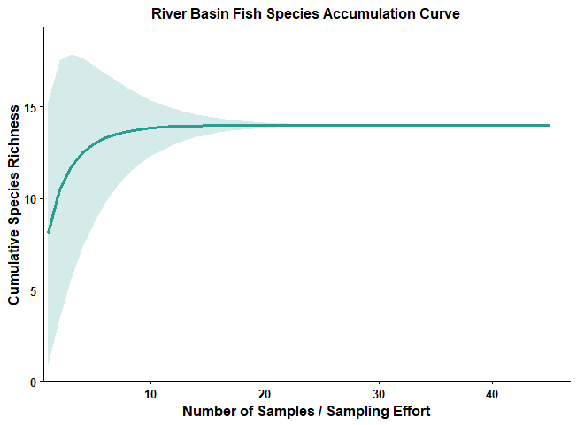

```r
res_acc_pooled <- specaccum_plot(
  data       = fish_inventory,
  group_col  = "Habitat",
  by_group   = FALSE,
  method     = "exact",
  line_color = "#2A9D8F",
  ci         = 1.96,
  show_ci    = TRUE,
  title      = "River Basin Fish Species Accumulation Curve"
)

# Render pooled curve
res_acc_pooled$Plot
```

#### 1.21.3.2 Style B: Comparative Multi-Habitat Accumulation Curves

By specifying `by_group = TRUE`, the function estimates accumulation curves separately for each habitat level, allowing direct visual comparison of species richness saturation rates across environmental strata:

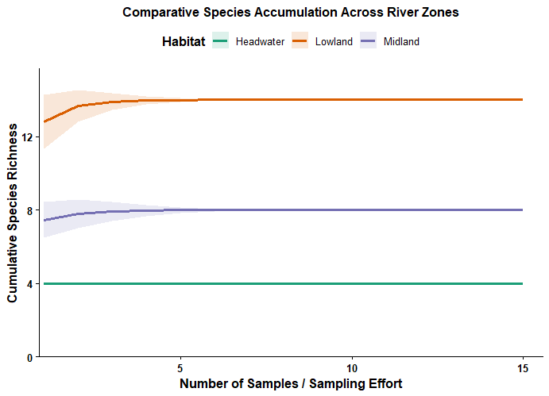

```r
res_acc_grouped <- specaccum_plot(
  data       = fish_inventory,
  group_col  = "Habitat",
  by_group   = TRUE,
  method     = "exact",
  palette    = "Dark2",
  show_ci    = TRUE,
  title      = "Comparative Species Accumulation Across River Zones"
)

res_acc_grouped$Plot
```

### 1.21.4 Model Inspection and Numerical Summaries

The returned list provides the underlying `vegan::specaccum` object and the tidy data frame containing exact site counts, expected richness, standard deviations, and confidence intervals:

```r
# 1. Inspect accumulation curve trajectory table (First 8 sample intervals)
head(res_acc_pooled$Curve_Data, 8)
```

```
#>   Sites  Richness       SD      Lower    Upper
#> 1     1  8.088889 3.656484  0.9221799 15.25560
#> 2     2 10.459596 3.597171  3.4091399 17.51005
#> 3     3 11.723679 3.137314  5.5745433 17.87281
#> 4     4 12.487298 2.638540  7.3157596 17.65884
#> 5     5 12.978136 2.187067  8.6914857 17.26479
#> 6     6 13.304413 1.798105  9.7801273 16.82870
#> 7     7 13.525083 1.469828 10.6442192 16.40595
#> 8     8 13.675544 1.195670 11.3320315 16.01906
```

```r
# 2. Inspect grouped curve summary table preview
head(res_acc_grouped$Curve_Data, 6)
```

```
#>       Group Sites Richness SD Lower Upper
#> 1 Headwater     1        4  0     4     4
#> 2 Headwater     2        4  0     4     4
#> 3 Headwater     3        4  0     4     4
#> 4 Headwater     4        4  0     4     4
#> 5 Headwater     5        4  0     4     4
#> 6 Headwater     6        4  0     4     4
```

## 1.22 Weighted Arithmetic Water Quality Index (WAWQI)

The `calc_wqi()` and `plot_wqi()` functions calculate and visualize the Weighted Arithmetic Water Quality Index (WAWQI) across spatial monitoring stations and temporal sampling campaigns. In fisheries management and aquatic environmental impact assessments, raw multi-parameter water chemistry matrices (e.g., pH, Dissolved Oxygen, Biological Oxygen Demand, Total Dissolved Solids, Turbidity) can be difficult to interpret individually.

The WAWQI methodology aggregates multiple physico-chemical metrics into a single score that quantifies overall ecosystem water quality. The functions compute parameter-specific unit weights, derive quality ratings, handle station replicates with Student’s $t$-distribution 95% confidence intervals, assign ecological suitability tiers, and generate publication-ready bar and lollipop plots overlaid with regulatory benchmark bands.

### 1.22.1 Conceptual Framework and Mathematical Formulation

Let $n$ denote the number of evaluated water quality parameters. Each parameter is evaluated against recommended regulatory thresholds (e.g., WHO, BIS, or national environmental standards).

#### 1.22.1.1 Unit Weighting Factor ($W_i$)

The unit weight $W_i$ for the $i$-th parameter is inversely proportional to its standard permissible limit ($S_i$), ensuring that toxic or sensitive parameters (such as low dissolved oxygen thresholds or high pesticide levels) carry greater weight in the final index:

$$W_i = \frac{K}{S_i} = \frac{1}{S_i
\sum_{j=1}^n \frac{1}{S_j}}$$

where $K = \frac{1}{\sum_{j=1}^n (1 / S_j)}$ is the proportionality normalization constant, ensuring that $\sum_{i=1}^n W_i = 1.0$.

#### 1.22.1.2 Quality Rating Scale ($Q_i$)

The sub-index rating $Q_i$ for parameter $i$ reflects the observed concentration ($V_i$) relative to its ideal standard value ($V_0$) and standard limit ($S_i$):

$$Q_i = \frac{V_i - V_0}{S_i - V_0} \times
100$$

For pollutants and nutrient parameters (e.g., BOD, TDS, Turbidity), the ideal zero-effect concentration is $V_0 = 0\text{ mg/L}$. For physiological parameters with specific natural equilibria: - pH: $V_0 = 7.0$ (neutral baseline) - Dissolved Oxygen (DO): $V_0 = 14.6\text{ mg/L}$ (theoretical saturation baseline at standard temperature and pressure), formulated as:
$$Q_{\text{DO}} = \frac{14.6 -
V_{\text{DO}}}{14.6 - S_{\text{DO}}} \times 100$$
Lower dissolved oxygen concentrations yield higher $Q_i$ penalty scores.

#### 1.22.1.3 Overall Index Aggregation and Classification

The aggregate WAWQI is computed as the weighted arithmetic mean of all sub-indices:

$$\text{WAWQI} = \frac{\sum_{i=1}^n Q_i
W_i}{\sum_{i=1}^n W_i} = \sum_{i=1}^n Q_i W_i$$

Ecological water quality ratings are classified according to established benchmark boundaries: - $0 \le \text{WAWQI} \le 25$: Excellent Water Quality (Pristine aquatic habitat) - $26 \le \text{WAWQI} \le 50$: Good Water Quality (Suitable for aquaculture and fisheries) - $51 \le \text{WAWQI} \le 75$: Poor Water Quality (Threatened aquatic biodiversity) - $76 \le \text{WAWQI} \le 100$: Very Poor Water Quality (Severe eutrophication and habitat degradation) - $\text{WAWQI} > 100$: Unsuitable for Aquatic Life (Acute toxicity / critical hypoxia)

### 1.22.2 In-Vignette Data Generation

We simulate a seasonal river biomonitoring dataset evaluating five standard water quality parameters (pH, DO, BOD, TDS, and Turbidity) across four monitoring stations (`Station_1` to `Station_4`), with 6 replicate water samples collected at each station:

```r
set.seed(2026)
n_reps <- 6

stations <- c("Station_1 (Upstream)", "Station_2 (Agricultural)", "Station_3 (Urban Discharge)", "Station_4 (Estuarine Mouth)")

wqi_survey <- do.call(rbind, lapply(stations, function(stn) {
  # Parameter baseline values reflecting an anthropogenic pollution gradient
  param_means <- switch(stn,
    "Station_1 (Upstream)"        = c(pH = 7.4, DO = 8.8, BOD = 1.8, TDS = 140, Turbidity = 2.5),
    "Station_2 (Agricultural)"    = c(pH = 7.8, DO = 6.8, BOD = 3.6, TDS = 320, Turbidity = 4.8),
    "Station_3 (Urban Discharge)" = c(pH = 8.3, DO = 4.1, BOD = 8.5, TDS = 680, Turbidity = 9.4),
    "Station_4 (Estuarine Mouth)" = c(pH = 7.9, DO = 5.4, BOD = 5.2, TDS = 510, Turbidity = 6.2)
  )

  data.frame(
    Station   = stn,
    pH        = rnorm(n_reps, mean = param_means["pH"], sd = 0.2),
    DO        = rnorm(n_reps, mean = param_means["DO"], sd = 0.35),
    BOD       = rnorm(n_reps, mean = param_means["BOD"], sd = 0.4),
    TDS       = rnorm(n_reps, mean = param_means["TDS"], sd = 25),
    Turbidity = rnorm(n_reps, mean = param_means["Turbidity"], sd = 0.5)
  )
}))

head(wqi_survey, 6)
```

```
#>                Station       pH       DO       BOD      TDS Turbidity
#> 1 Station_1 (Upstream) 7.504118 8.542699 1.7114254 119.8820  2.524103
#> 2 Station_1 (Upstream) 7.184062 8.442957 1.7096734 157.2437  3.454042
#> 3 Station_1 (Upstream) 7.427848 8.839744 0.7812474 131.7832  3.365472
#> 4 Station_1 (Upstream) 7.383050 8.634173 2.3388006 135.8830  2.529073
#> 5 Station_1 (Upstream) 7.266672 8.657125 2.0465633 105.1993  2.822664
#> 6 Station_1 (Upstream) 6.896782 8.544348 1.8870257 176.6456  3.362814
```

### 1.22.3 Calculating Index Scores and Station Summaries

Run `calc_wqi()` to derive individual replicate sub-indices and station-level summary statistics:

```r
res_wqi <- calc_wqi(
  data      = wqi_survey,
  id_col    = "Station",
  standards = c(
    pH        = 8.5,
    DO        = 5.0,
    BOD       = 5.0,
    TDS       = 500,
    Turbidity = 5.0
  ),
  ci        = 0.95
)

# Station-level summary table with 95% Confidence Intervals
res_wqi$Summary_Data
```

```
#>                           Station N WQI_Mean WQI_SD WQI_SE WQI_LCI WQI_UCI
#> Mean         Station_1 (Upstream) 6    47.06   1.53   0.63   45.45   48.67
#> Mean1    Station_2 (Agricultural) 6    76.88   4.29   1.75   72.37   81.39
#> Mean2 Station_3 (Urban Discharge) 6   146.40   4.36   1.78  141.83  150.98
#> Mean3 Station_4 (Estuarine Mouth) 6   100.18   4.02   1.64   95.96  104.39
#>           Status
#> Mean        Good
#> Mean1  Very Poor
#> Mean2 Unsuitable
#> Mean3 Unsuitable
```

### 1.22.4 Visualization Styles

`plot_wqi()` provides both columnar bar charts and lollipop geometries with optional background benchmark classification shading.

#### 1.22.4.1 Style A: Status-Filled Bar Chart with Benchmark Bands and 95% CI Whiskers (Default)

Displays station scores against regulatory classification tiers, attaching 95% confidence intervals to convey measurement variability:

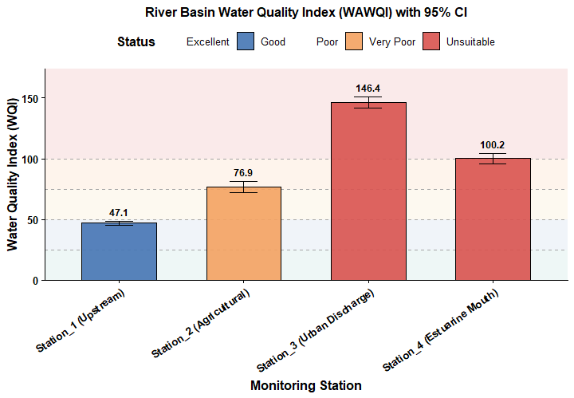

```r
p_wqi_bar <- plot_wqi(
  data       = res_wqi,
  id_col     = "Station",
  type       = "bar",
  show_ci    = TRUE,
  show_bands = TRUE,
  title      = "River Basin Water Quality Index (WAWQI) with 95% CI"
)

# Render publication plot
p_wqi_bar
```

#### 1.22.4.2 Style B: Lollipop Display

Provides an alternative lollipop format without background shading, focusing on discrete station comparisons:

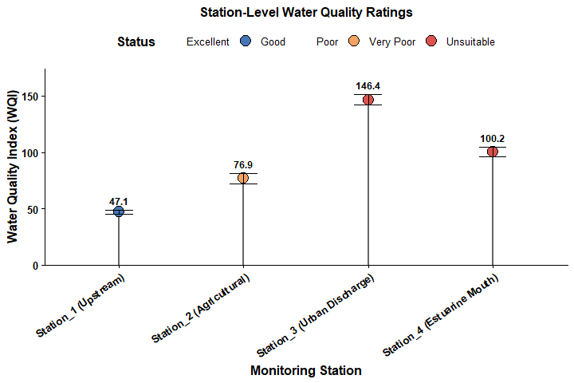

```r
p_wqi_lollipop <- plot_wqi(
  data       = res_wqi,
  id_col     = "Station",
  type       = "lollipop",
  show_ci    = TRUE,
  show_bands = FALSE,
  title      = "Station-Level Water Quality Ratings"
)

p_wqi_lollipop
```

### 1.22.5 Model Inspection and Replicate Data

Inspect individual replicate sub-indices ($Q_i$) and corresponding final sample scores:

```r
# 1. Preview individual replicate evaluations (first 6 samples)
head(res_wqi$Replicate_Data, 6)
```

```
#>                Station       pH       DO       BOD      TDS Turbidity  Q_pH
#> 1 Station_1 (Upstream) 7.504118 8.542699 1.7114254 119.8820  2.524103 33.61
#> 2 Station_1 (Upstream) 7.184062 8.442957 1.7096734 157.2437  3.454042 12.27
#> 3 Station_1 (Upstream) 7.427848 8.839744 0.7812474 131.7832  3.365472 28.52
#> 4 Station_1 (Upstream) 7.383050 8.634173 2.3388006 135.8830  2.529073 25.54
#> 5 Station_1 (Upstream) 7.266672 8.657125 2.0465633 105.1993  2.822664 17.78
#> 6 Station_1 (Upstream) 6.896782 8.544348 1.8870257 176.6456  3.362814  0.00
#>    Q_DO Q_BOD Q_TDS Q_Turbidity   WQI
#> 1 63.10 34.23 23.98       50.48 46.64
#> 2 64.14 34.19 31.45       69.08 48.62
#> 3 60.00 15.62 26.36       67.31 44.46
#> 4 62.14 46.78 27.18       50.58 48.58
#> 5 61.90 40.93 21.04       56.45 47.23
#> 6 63.08 37.74 35.33       67.26 46.81
```

```r
# 2. Inspect station-level summary statistics
res_wqi$Summary_Data[, c("Station", "N", "WQI_Mean", "WQI_SE", "Status")]
```

```
#>                           Station N WQI_Mean WQI_SE     Status
#> Mean         Station_1 (Upstream) 6    47.06   0.63       Good
#> Mean1    Station_2 (Agricultural) 6    76.88   1.75  Very Poor
#> Mean2 Station_3 (Urban Discharge) 6   146.40   1.78 Unsuitable
#> Mean3 Station_4 (Estuarine Mouth) 6   100.18   1.64 Unsuitable
```

## 1.23 Heavy Metal Pollution & Ecotoxicological Indices

The `calc_metal_indices()` and `plot_metal_indices()` functions evaluate heavy metal pollution in aquatic ecosystems (water columns, riverbed sediments, and fish tissue matrices). Aquatic toxicology and environmental impact assessments require multi-element risk indices to convert raw trace element concentrations into standardized toxicological risk scores.

The visualization function `plot_metal_indices()` renders column and lollipop graphics with 95% confidence intervals and dashed benchmark thresholds.

### 1.23.1 Conceptual Framework and Mathematical Formulation

Let $C_i$ denote the observed concentration of the $i$-th heavy metal, and let $S_i$ denote its corresponding national or international drinking/aquatic life permissible standard limit.

#### 1.23.1.1 Contamination Factor ($CF_i$)

The base metric for single-metal contamination is the ratio:

$$CF_i = \frac{C_i}{S_i}$$

#### 1.23.1.2 Heavy Metal Evaluation Index (HEI) & Contamination Degree ($C_d$)

HEI expresses the cumulative additive load across all $n$ analyzed trace metals:

$$\text{HEI} = \sum_{i=1}^n CF_i =
\sum_{i=1}^n \frac{C_i}{S_i}$$

Benchmark classification: $\text{HEI} < 10$ (Low); $10 \le \text{HEI} \le 20$ (Medium); $\text{HEI} > 20$ (High pollution).

The Degree of Contamination ($C_d$) computes the net excess above the permissible threshold ($CF_i = 1$):

$$C_d = \sum_{i=1}^n (CF_i -
1)$$

Benchmark classification: $C_d < 6$ (Low); $6 \le C_d < 12$ (Moderate); $C_d \ge 12$ (High contamination).

#### 1.23.1.3 Pollution Load Index (PLI)

Originally formulated by Tomlinson et al., PLI calculates the geometric mean of contamination factors:

$$\text{PLI} = \left( \prod_{i=1}^n CF_i
\right)^{\frac{1}{n}} = \sqrt[n]{CF_1 \times CF_2 \times \dots \times
CF_n}$$

Interpretation threshold: $\text{PLI} \le 1.0$ indicates baseline unpolluted conditions, whereas $\text{PLI} > 1.0$ indicates progressive heavy metal deterioration.

#### 1.23.1.4 Comprehensive Nemerow Pollution Index ($P_N$)

Evaluates total quality while giving special weight to the worst single pollutant:

$$P_N = \sqrt{\frac{\overline{CF}^2 +
CF_{\max}^2}{2}}$$

where $\overline{CF} = \frac{1}{n} \sum CF_i$ is the average contamination factor and $CF_{\max}$ is the maximum observed single contamination factor.

#### 1.23.1.5 Heavy Metal Pollution Index (HPI)

Computes a weighted arithmetic aggregation:

$$\text{HPI} = \frac{\sum_{i=1}^n W_i
Q_i}{\sum_{i=1}^n W_i}$$

where unit weights are inversely proportional to guidelines ($W_i = 1 / S_i$), and sub-index ratings are $Q_i = (C_i / S_i) \times 100$. The critical threshold is $\text{HPI} = 100$; values exceeding $100$ indicate critical metal pollution unsuitable for aquatic habitats.

### 1.23.2 In-Vignette Data Generation

We simulate a river basin heavy metal survey measuring six trace elements ($\mu\text{g/L}$): Arsenic (`As`), Cadmium (`Cd`), Chromium (`Cr`), Copper (`Cu`), Lead (`Pb`), and Zinc (`Zn`) across five monitoring reaches with 5 sample replicates per reach:

```r
set.seed(2121)
n_reps <- 5

sites <- c("Site_1 (Forest)", "Site_2 (Mining)", "Site_3 (Smelting)", "Site_4 (Urban)", "Site_5 (Estuary)")

metal_survey <- do.call(rbind, lapply(sites, function(stn) {
  # Baseline metal concentrations (ug/L)
  means <- switch(stn,
    "Site_1 (Forest)"   = c(As = 1.2,  Cd = 0.2, Cr = 4.5,  Cu = 45,   Pb = 1.1,  Zn = 120),
    "Site_2 (Mining)"   = c(As = 18.5, Cd = 5.8, Cr = 68.0, Cu = 1850, Pb = 24.5, Zn = 4200),
    "Site_3 (Smelting)" = c(As = 26.0, Cd = 8.2, Cr = 95.0, Cu = 2600, Pb = 38.0, Zn = 5800),
    "Site_4 (Urban)"    = c(As = 6.5,  Cd = 1.4, Cr = 28.0, Cu = 420,  Pb = 8.5,  Zn = 1450),
    "Site_5 (Estuary)"  = c(As = 4.2,  Cd = 0.9, Cr = 16.5, Cu = 210,  Pb = 4.2,  Zn = 850)
  )

  data.frame(
    Station = stn,
    As = pmax(0.1,  rnorm(n_reps, mean = means["As"], sd = means["As"] * 0.12)),
    Cd = pmax(0.05, rnorm(n_reps, mean = means["Cd"], sd = means["Cd"] * 0.15)),
    Cr = pmax(0.5,  rnorm(n_reps, mean = means["Cr"], sd = means["Cr"] * 0.10)),
    Cu = pmax(2.0,  rnorm(n_reps, mean = means["Cu"], sd = means["Cu"] * 0.12)),
    Pb = pmax(0.1,  rnorm(n_reps, mean = means["Pb"], sd = means["Pb"] * 0.14)),
    Zn = pmax(5.0,  rnorm(n_reps, mean = means["Zn"], sd = means["Zn"] * 0.10))
  )
}))

head(metal_survey, 6)
```

```
#>           Station        As        Cd        Cr         Cu        Pb        Zn
#> 1 Site_1 (Forest)  1.085621 0.1844308  4.358769   45.40370  1.167778  132.3617
#> 2 Site_1 (Forest)  1.081720 0.1949841  4.678270   49.65574  1.101673  134.3707
#> 3 Site_1 (Forest)  1.209242 0.1466376  3.586198   46.37561  1.233846  124.5558
#> 4 Site_1 (Forest)  1.160399 0.1911586  4.680002   48.77459  1.350155  120.0001
#> 5 Site_1 (Forest)  1.220738 0.1577921  4.466422   41.96124  1.161292  118.0802
#> 6 Site_2 (Mining) 18.100377 4.5200358 71.436150 1746.83159 20.417828 4330.6734
```

### 1.23.3 Calculating Heavy Metal Indices

Run `calc_metal_indices()` using standard international drinking and aquatic life guideline limits:

```r
res_metals <- calc_metal_indices(
  data      = metal_survey,
  id_col    = "Station",
  standards = c(
    As = 10,
    Cd = 3,
    Cr = 50,
    Cu = 2000,
    Pb = 10,
    Zn = 3000
  ),
  ci        = 0.95
)

# Station summary statistics table (Means, 95% CIs, and assigned status)
head(res_metals$Summary_Data[, c("Station", "HPI_Mean", "HPI_Status", "PLI_Mean", "PLI_Status")], 5)
```

```
#>                 Station HPI_Mean        HPI_Status PLI_Mean PLI_Status
#> Mean    Site_1 (Forest)     8.08          Suitable     0.06 Unpolluted
#> Mean1   Site_2 (Mining)   205.36 Polluted/Critical     1.62   Polluted
#> Mean2 Site_3 (Smelting)   295.52 Polluted/Critical     2.30   Polluted
#> Mean3    Site_4 (Urban)    56.92          Suitable     0.49 Unpolluted
#> Mean4  Site_5 (Estuary)    34.26          Suitable     0.29 Unpolluted
```

### 1.23.4 Visualization Styles

`plot_metal_indices()` creates status-filled charts with 95% confidence intervals and dashed benchmark thresholds.

#### 1.23.4.1 Style A: Heavy Metal Pollution Index (HPI) with Critical Threshold (Default)

Displays mean HPI values with 95% confidence intervals against the critical threshold line ($\text{HPI} = 100$):

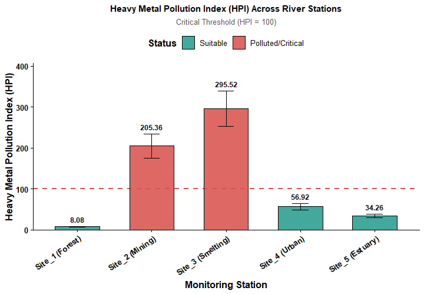

```r
p_hpi <- plot_metal_indices(
  data           = res_metals,
  metric         = "HPI",
  id_col         = "Station",
  type           = "bar",
  show_ci        = TRUE,
  show_threshold = TRUE,
  palette        = "auto",
  title          = "Heavy Metal Pollution Index (HPI) Across River Stations"
)

# Render HPI plot
p_hpi
```

#### 1.23.4.2 Style B: Pollution Load Index (PLI) Lollipop Plot

Visualizes the multi-metal Pollution Load Index (PLI) relative to the baseline threshold ($\text{PLI} = 1.0$):

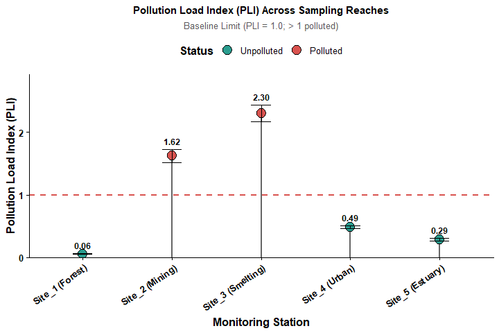

```r
p_pli <- plot_metal_indices(
  data           = res_metals,
  metric         = "PLI",
  id_col         = "Station",
  type           = "lollipop",
  show_ci        = TRUE,
  show_threshold = TRUE,
  palette        = "auto",
  title          = "Pollution Load Index (PLI) Across Sampling Reaches"
)

p_pli
```

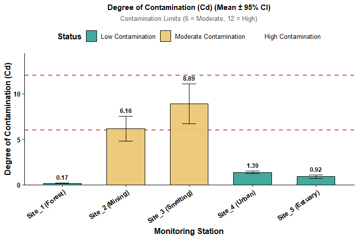

```r
p_cd <- plot_metal_indices(
  data           = res_metals,
  metric         = "Cd",
  id_col         = "Station",
  type           = "bar",
  show_ci        = TRUE,
  show_threshold = TRUE,
  palette        = "auto"
)

p_cd
```

### 1.23.5 Model Inspection and Replicate Contamination Factors

Inspect sample-level contamination factors ($CF_i$) and overall indices:

```r
# 1. Preview replicate contamination factors and computed indices (first 4 samples)
head(res_metals$Replicate_Data[, c("Station", "CF_As", "CF_Cd", "CF_Pb", "HPI", "PLI")], 4)
```

```
#>           Station CF_As CF_Cd CF_Pb  HPI  PLI
#> 1 Site_1 (Forest)  0.11  0.06  0.12 8.08 0.06
#> 2 Site_1 (Forest)  0.11  0.06  0.11 8.19 0.07
#> 3 Site_1 (Forest)  0.12  0.05  0.12 7.61 0.06
#> 4 Site_1 (Forest)  0.12  0.06  0.14 8.71 0.07
```

```r
# 2. Comprehensive Station Summary
res_metals$Summary_Data[, c("Station", "HEI_Mean", "HEI_Status", "Nemerow_PN_Mean", "Nemerow_Status")]
```

```
#>                 Station HEI_Mean HEI_Status Nemerow_PN_Mean      Nemerow_Status
#> Mean    Site_1 (Forest)     0.45        Low            0.10               Clean
#> Mean1   Site_2 (Mining)    10.14     Medium            2.14 Moderately Polluted
#> Mean2 Site_3 (Smelting)    14.49     Medium            3.11    Heavily Polluted
#> Mean3    Site_4 (Urban)     3.20        Low            0.73       Warning Limit
#> Mean4  Site_5 (Estuary)     1.85        Low            0.37               Clean
```

## 1.24 Descriptive Statistics & Automated Table Summaries

The `summarize_obs()` function generates comprehensive descriptive summaries for multi-parameter limnological, water quality, and fisheries biometric matrices. Before applying formal parametric or multivariate models, empirical researchers require rigorous tabular summaries detailing central tendency, variance, standard errors, and sample dispersion across spatial or experimental factor levels.

The function computes both parametric metrics (Sample Size $N$, Arithmetic Mean $\bar{x}$, Standard Deviation $s$, Standard Error of the Mean $\text{SE}$) and non-parametric metrics (Median $\tilde{x}$, Minimum, Maximum), constructs ready-to-publish composite notation ($\bar{x} \pm s$), accommodates multi-factor grouping strata, and supports direct export to formatted Excel workbooks (`.xlsx`) or comma-separated tables (`.csv`).

### 1.24.1 Conceptual Framework and Statistical Formulation

Let $\{x_1, x_2, \dots, x_n\}$ denote a set of $n$ complete observations recorded for a continuous aquatic variable $X$ within a given sampling stratum.

#### 1.24.1.1 Parametric Estimators of Central Tendency and Dispersion

1. Arithmetic Mean ($\bar{x}$):
   $$\bar{x} = \frac{1}{n} \sum_{i=1}^n
   x_i$$
2. Sample Standard Deviation ($s$): Measures sample dispersion around the mean using Bessel’s correction for unbiased estimation:
   $$s = \sqrt{\frac{1}{n - 1} \sum_{i=1}^n (x_i -
   \bar{x})^2} \quad (n > 1)$$
3. Standard Error of the Mean ($\text{SE}$): Quantifies the theoretical precision of the sample mean as an estimator of the true population parameter $\mu$:
   $$\text{SE} = \frac{s}{\sqrt{n}}$$

#### 1.24.1.2 Non-Parametric Order Statistics

For non-normal, skewed, or zero-inflated aquatic measurements (e.g., bacterial coliform densities, chemical trace contaminants):

1. Sample Median ($\tilde{x}$): The 50th percentile order statistic, robust against extreme outlier observations:
   $$\tilde{x} = \begin{cases}
   x_{\left(\frac{n+1}{2}\right)} & \text{if } n \text{ is odd} \\
   \frac{1}{2}\left(x_{\left(\frac{n}{2}\right)} + x_{\left(\frac{n}{2} +
   1\right)}\right) & \text{if } n \text{ is even}
   \end{cases}$$
2. Sample Extrema:
   $$\text{Min} =
   x_{(1)}, \quad \text{Max} = x_{(n)}$$

### 1.24.2 In-Vignette Data Generation

We simulate a river basin fisheries survey evaluating fish Total Length (cm), Total Weight (g), and Condition Factor ($K$) across 60 specimens sampled across three distinct River Systems (`Karnafuli`, `Halda`, `Sangu`) during two hydrologic periods (`Dry`, `Wet`):

```r
set.seed(2222)
n_per_combo <- 10

systems <- c("Karnafuli", "Halda", "Sangu")
seasons <- c("Dry", "Wet")

survey_grid <- expand.grid(River = systems, Season = seasons)

survey_rows <- lapply(seq_len(nrow(survey_grid)), function(i) {
  rv <- as.character(survey_grid$River[i])
  sn <- as.character(survey_grid$Season[i])

  mean_len <- switch(rv, "Karnafuli" = 28.5, "Halda" = 34.0, "Sangu" = 22.0)
  if (sn == "Wet") mean_len <- mean_len * 1.15

  len <- rnorm(n_per_combo, mean = mean_len, sd = 3.2)
  # Allometric length-weight relationship: W = 0.012 * L^3.05
  wt  <- 0.012 * (len^3.05) + rnorm(n_per_combo, mean = 0, sd = 15)
  k   <- (wt / (len^3)) * 100

  data.frame(
    River            = rv,
    Season           = sn,
    Total_Length_cm  = pmax(10, len),
    Body_Weight_g    = pmax(20, wt),
    Condition_Factor = k,
    stringsAsFactors = FALSE
  )
})

fish_morph_survey <- do.call(rbind, survey_rows)
head(fish_morph_survey, 6)
```

```
#>       River Season Total_Length_cm Body_Weight_g Condition_Factor
#> 1 Karnafuli    Dry        27.41820      324.7617         1.575607
#> 2 Karnafuli    Dry        31.50533      432.1249         1.381839
#> 3 Karnafuli    Dry        34.06070      552.2470         1.397567
#> 4 Karnafuli    Dry        30.72824      369.5970         1.273841
#> 5 Karnafuli    Dry        29.97935      401.8828         1.491533
#> 6 Karnafuli    Dry        27.49172      304.6220         1.466073
```

### 1.24.3 Analytical Execution

`summarize_obs()` supports global overall summaries as well as single-factor and multi-factor stratified analyses.

#### 1.24.3.1 Style A: Single-Factor Grouped Summary (Across River Systems)

Summarizes length, weight, and condition factor across river systems:

```r
res_summary_river <- summarize_obs(
  data   = fish_morph_survey,
  vars   = c("Total_Length_cm", "Body_Weight_g", "Condition_Factor"),
  group  = "River",
  digits = 2
)

# Display tabular summary
res_summary_river[, c("River", "Variable", "N", "Mean_SD", "SE", "Median", "Min", "Max")]
```

```
#>       River         Variable  N         Mean_SD    SE Median    Min     Max
#> 1     Halda  Total_Length_cm 20    35.47 ± 3.74  0.84  34.54  30.10   43.62
#> 2 Karnafuli  Total_Length_cm 20    31.87 ± 3.09  0.69  32.24  25.00   37.11
#> 3     Sangu  Total_Length_cm 20    23.56 ± 4.16  0.93  23.28  17.32   31.51
#> 4     Halda    Body_Weight_g 20 663.07 ± 227.50 50.87 600.84 396.03 1211.61
#> 5 Karnafuli    Body_Weight_g 20 474.78 ± 129.99 29.07 480.26 228.20  730.16
#> 6     Sangu    Body_Weight_g 20 195.32 ± 112.50 25.16 177.42  59.98  452.93
#> 7     Halda Condition_Factor 20     1.44 ± 0.04  0.01   1.44   1.34    1.49
#> 8 Karnafuli Condition_Factor 20     1.43 ± 0.06  0.01   1.44   1.27    1.58
#> 9     Sangu Condition_Factor 20     1.34 ± 0.13  0.03   1.38   0.99    1.50
```

#### 1.24.3.2 Style B: Two-Factor Stratified Summary (River x Season Interaction)

Evaluates biometric traits across both River System and Season simultaneously:

```r
res_summary_factorial <- summarize_obs(
  data   = fish_morph_survey,
  vars   = c("Total_Length_cm", "Body_Weight_g"),
  group  = c("River", "Season"),
  digits = 2
)

head(res_summary_factorial[, c("River", "Season", "Variable", "Mean_SD", "SE", "Median")], 6)
```

```
#>       River Season        Variable      Mean_SD   SE Median
#> 1     Halda    Dry Total_Length_cm 32.87 ± 1.58 0.50  33.18
#> 2 Karnafuli    Dry Total_Length_cm 30.96 ± 2.52 0.80  31.12
#> 3     Sangu    Dry Total_Length_cm 20.95 ± 2.50 0.79  20.82
#> 4     Halda    Wet Total_Length_cm 38.07 ± 3.47 1.10  37.24
#> 5 Karnafuli    Wet Total_Length_cm 32.78 ± 3.45 1.09  32.82
#> 6     Sangu    Wet Total_Length_cm 26.17 ± 3.91 1.24  26.17
```

### 1.24.4 Inspection and Formatted Output

The returned data frame provides publication-ready string representations alongside raw numeric columns suitable for downstream reporting or plotting:

```r
# 1. Structure of the exported summary table
str(res_summary_river)
```

```
#> 'data.frame':    9 obs. of  10 variables:
#>  $ River   : chr  "Halda" "Karnafuli" "Sangu" "Halda" ...
#>  $ Variable: chr  "Total_Length_cm" "Total_Length_cm" "Total_Length_cm" "Body_Weight_g" ...
#>  $ N       : int  20 20 20 20 20 20 20 20 20
#>  $ Mean    : num  35.5 31.9 23.6 663.1 474.8 ...
#>  $ SD      : num  3.74 3.09 4.16 227.5 129.99 ...
#>  $ SE      : num  0.84 0.69 0.93 50.87 29.07 ...
#>  $ Median  : num  34.5 32.2 23.3 600.8 480.3 ...
#>  $ Min     : num  30.1 25 17.3 396 228.2 ...
#>  $ Max     : num  43.6 37.1 31.5 1211.6 730.2 ...
#>  $ Mean_SD : chr  "35.47 ± 3.74" "31.87 ± 3.09" "23.56 ± 4.16" "663.07 ± 227.50" ...
```

```r
# 2. Inspect Mean +/- SD column for direct manuscript inclusion
res_summary_river[, c("River", "Variable", "Mean_SD")]
```

```
#>       River         Variable         Mean_SD
#> 1     Halda  Total_Length_cm    35.47 ± 3.74
#> 2 Karnafuli  Total_Length_cm    31.87 ± 3.09
#> 3     Sangu  Total_Length_cm    23.56 ± 4.16
#> 4     Halda    Body_Weight_g 663.07 ± 227.50
#> 5 Karnafuli    Body_Weight_g 474.78 ± 129.99
#> 6     Sangu    Body_Weight_g 195.32 ± 112.50
#> 7     Halda Condition_Factor     1.44 ± 0.04
#> 8 Karnafuli Condition_Factor     1.43 ± 0.06
#> 9     Sangu Condition_Factor     1.34 ± 0.13
```

## 1.25 Distributional Histograms & Density Curves

The `plot_histogram()` function generates publication-grade frequency distributions, empirical kernel density estimates (KDE), and theoretical normal curves for fisheries morphometrics and environmental water quality metrics. Inspecting distributional skewness, modality (e.g., polymodal fish cohorts), and kurtosis is a prerequisite for evaluating parametric model assumptions (ANOVA, linear regression) and detecting recruitment pulses in length-frequency data.

The function supports automatic dynamic scaling between raw counts and probability density space, overlays theoretical Gaussian profiles with empirical kernel fits, displays parametric mean (solid red line) and non-parametric median (dashed blue line) references, and supports multi-panel faceting across environmental strata.

### 1.25.1 Conceptual Framework and Statistical Formulation

Let $\{x_1, x_2, \dots, x_n\}$ denote $n$ independent observations of a continuous fisheries variable $X$ (e.g., fork length or body weight).

#### 1.25.1.1 Empirical Kernel Density Estimation (KDE)

To estimate the probability density function $f(x)$ continuously without discretization artifacts, kernel smoothing is defined as:

$$\hat{f}_h(x) = \frac{1}{n h}
\sum_{i=1}^n K\left(\frac{x - x_i}{h}\right)$$

where $K(\cdot)$ is a standard Gaussian kernel function $K(u) = \frac{1}{\sqrt{2\pi}} e^{-\frac{1}{2}u^2}$ and $h > 0$ is the bandwidth smoothing parameter.

#### 1.25.1.2 Theoretical Gaussian Overlay

When `add_normal = TRUE` is enabled, the function projects the parameterized normal distribution curve evaluated at sample estimates $(\bar{x}, s)$:

$$f(x; \bar{x}, s) = \frac{1}{s
\sqrt{2\pi}} \exp\left( -\frac{(x - \bar{x})^2}{2 s^2}
\right)$$

Discrepancies between the empirical kernel curve (red) and the theoretical Gaussian curve (green dashed) highlight skewness and kurtosis deviations from normality.

#### 1.25.1.3 Central Tendency Reference Lines

The function evaluates asymmetry using the divergence between: - Sample Mean: $\bar{x} = \frac{1}{n} \sum_{i=1}^n x_i$ (solid red line) - Sample Median: $\tilde{x} = x_{(0.5)}$ (dashed blue line)

In right-skewed data (common in juvenile fish counts or pollutant spikes), $\bar{x} > \tilde{x}$, whereas left-skewed distributions exhibit $\bar{x} < \tilde{x}$.

### 1.25.2 In-Vignette Data Generation

We simulate a length-frequency fisheries survey measuring Total Length (cm) across 250 specimens of an estuarine fish population sampled across three estuarine habitats (`Mangrove Creek`, `Mudflat`, `Open Channel`):

```r
set.seed(2323)
n_fish <- 250

habitats <- sample(c("Mangrove Creek", "Mudflat", "Open Channel"), size = n_fish, replace = TRUE, prob = c(0.4, 0.35, 0.25))

# Simulate bimodal cohort growth
lengths <- vapply(habitats, function(hab) {
  cohort <- rbinom(1, size = 1, prob = 0.65) # Age-0 vs Age-1 cohort
  if (hab == "Mangrove Creek") {
    if (cohort == 1) rnorm(1, 14.5, 1.8) else rnorm(1, 22.0, 2.1)
  } else if (hab == "Mudflat") {
    if (cohort == 1) rnorm(1, 18.2, 2.0) else rnorm(1, 26.5, 2.4)
  } else {
    if (cohort == 1) rnorm(1, 22.8, 2.2) else rnorm(1, 31.0, 2.8)
  }
}, numeric(1))

estuary_fish <- data.frame(
  Habitat      = factor(habitats),
  Total_Length = pmax(8.0, lengths)
)

head(estuary_fish, 6)
```

```
#>          Habitat Total_Length
#> 1   Open Channel     29.48856
#> 2   Open Channel     20.06740
#> 3 Mangrove Creek     14.41802
#> 4 Mangrove Creek     26.79226
#> 5        Mudflat     19.81244
#> 6   Open Channel     27.19829
```

### 1.25.3 Visualization Styles

`plot_histogram()` provides single-distribution diagnostics with distribution curves and comparative multi-panel faceted views.

#### 1.25.3.1 Style A: Overall Distribution with Density, Normal Fit & Reference Baselines

Overlays the empirical kernel density curve, theoretical Gaussian curve, and mean/median reference lines:

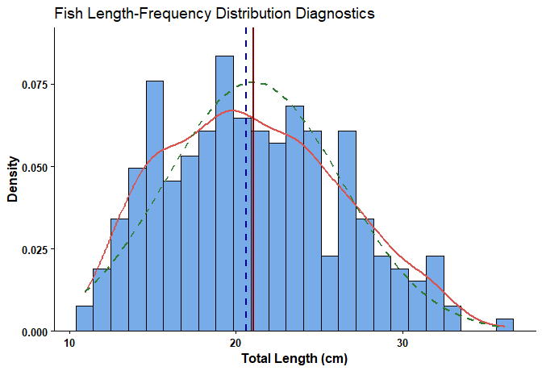

```r
p_hist_single <- plot_histogram(
  data        = estuary_fish,
  x           = "Total_Length",
  bins        = 25,
  add_density = TRUE,
  add_normal  = TRUE,
  show_stats  = TRUE,
  xlab        = "Total Length (cm)",
  ylab        = "Density",
  title       = "Fish Length-Frequency Distribution Diagnostics"
)

# Render distribution plot
p_hist_single
```

#### 1.25.3.2 Style B: Faceted Distribution Across Habitats

Using `facet = TRUE` separates the length-frequency distribution across habitats into separate panels:

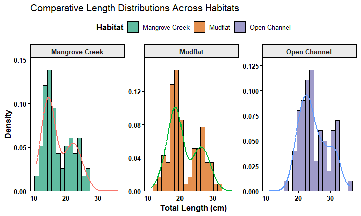

```r
p_hist_faceted <- plot_histogram(
  data        = estuary_fish,
  x           = "Total_Length",
  group       = "Habitat",
  facet       = TRUE,
  bins        = 20,
  add_density = TRUE,
  palette     = "Dark2",
  xlab        = "Total Length (cm)",
  title       = "Comparative Length Distributions Across Habitats"
)

p_hist_faceted
```

### 1.25.4 Inspection of Distributional Symmetry

Examine the divergence between mean and median to evaluate skewness:

```r
# 1. Compare central tendency benchmarks
mean_len   <- mean(estuary_fish$Total_Length)
median_len <- median(estuary_fish$Total_Length)
sd_len     <- sd(estuary_fish$Total_Length)

data.frame(
  Metric    = c("Mean (cm)", "Median (cm)", "Std. Deviation (cm)", "Skewness Offset"),
  Value     = round(c(mean_len, median_len, sd_len, mean_len - median_len), 3)
)
```

```
#>                Metric  Value
#> 1           Mean (cm) 21.033
#> 2         Median (cm) 20.625
#> 3 Std. Deviation (cm)  5.279
#> 4     Skewness Offset  0.408
```

## 1.26 Publication Bar & Lollipop Plots with Grouped Comparisons

The `plot_bar()` and `plot_lollipop()` functions render standardized bar and lollipop charts for categorical inventories, survey frequency counts, and metric aggregations across fisheries and aquatic ecology studies. Whether reporting catch frequencies across fishing gear types, species occurrence counts across sampling zones, or aggregated landings per river basin, these functions provide direct comparative visualization.

The functions provide three operating modes: 1. **Frequency Tabulation** (`y = NULL`): Computes categorical occurrence counts automatically. 2. **Metric Summary Aggregation** (`stat = "mean"` or `"sum"`): Aggregates continuous numeric responses across single or multi-factor grouping levels. 3. **Identity Plotting** (`stat = "identity"`): Plots pre-computed values directly.

In addition to standard bars (`type = "bar"`), lollipop geometry (`type = "lollipop"` or via `plot_lollipop()`) replaces solid bars with a slender stem and circular head, reducing ink-to-data ratio while enhancing clarity when comparing numerous categories. Both modes support side-by-side grouped arrangements (`position = "dodge"`), cumulative stacking (`position = "stack"`), 100% proportional fills (`position = "fill"`), automated numeric value labelling, coordinate flipping, and multi-column batch plotting.

### 1.26.1 Conceptual Framework and Aggregation Mechanics

Let a survey dataset contain observations indexed by $i = 1, \dots, n$ across categorical predictor $X$ with $K$ unique levels.

#### 1.26.1.1 Frequency Tabulation

When no response metric $Y$ is supplied, the plotted height for factor level $k$ is the sample frequency:

$$f_k = \sum_{i=1}^n \mathbb{I}(x_i =
k)$$

#### 1.26.1.2 Continuous Metric Aggregation

When numeric variable $Y$ is specified: - Mean Aggregation (`stat = "mean"`):
$$\bar{y}_k = \frac{1}{n_k} \sum_{i: x_i = k}
y_i$$
- Sum Aggregation (`stat = "sum"`):
$$Y_k = \sum_{i: x_i = k} y_i$$

#### 1.26.1.3 Proportional Stacking (`position = "fill"`)

When examining proportional composition across a secondary grouping factor $G$ with $M$ categories:

$$p_{km} = \frac{\sum_{i: x_i = k, g_i =
m} y_i}{\sum_{m'=1}^M \sum_{i: x_i = k, g_i = m'}
y_i}$$

The height of each stack normalizes to $1.0$ (or 100%), allowing comparison of relative composition independently of differences in total sample size.

### 1.26.2 In-Vignette Data Generation

We simulate a marine small-scale fisheries monitoring survey evaluating fish landings (kg per trip) and catch values across 90 fishing trips distributed among three Gear Types (`Gillnet`, `Longline`, `Trap`) across three Coastal Sectors (`North Sector`, `Central Sector`, `South Sector`):

```r
set.seed(2424)
n_trips <- 90

gears   <- sample(c("Gillnet", "Longline", "Trap"), size = n_trips, replace = TRUE, prob = c(0.45, 0.35, 0.20))
sectors <- sample(c("North Sector", "Central Sector", "South Sector"), size = n_trips, replace = TRUE)

landings_kg <- vapply(seq_len(n_trips), function(i) {
  g <- gears[i]
  base <- switch(g, "Gillnet" = 120, "Longline" = 210, "Trap" = 65)
  round(pmax(15, rnorm(1, mean = base, sd = base * 0.22)), 1)
}, numeric(1))

fisheries_catch_survey <- data.frame(
  Gear_Type   = factor(gears),
  Sector      = factor(sectors),
  Landings_kg = landings_kg
)

head(fisheries_catch_survey, 6)
```

```
#>   Gear_Type         Sector Landings_kg
#> 1  Longline Central Sector       227.8
#> 2  Longline   South Sector       225.8
#> 3   Gillnet   North Sector       146.2
#> 4  Longline Central Sector       178.5
#> 5  Longline Central Sector       244.7
#> 6      Trap   North Sector        75.6
```

### 1.26.3 Visualization Styles

#### 1.26.3.1 Style A: Mean Aggregation with Grouped Dodge Layout and Value Labels (Default)

Calculates mean landings per trip across Gear Types grouped by Coastal Sector, placing numeric value labels above each bar:

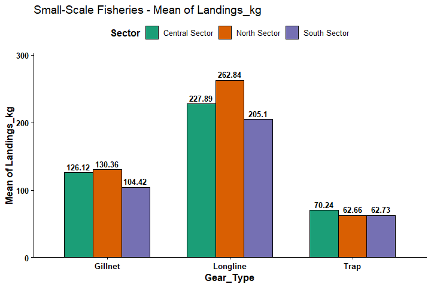

```r
p_bar_dodge <- plot_bar(
  data         = fisheries_catch_survey,
  x            = "Gear_Type",
  y            = "Landings_kg",
  group        = "Sector",
  stat         = "mean",
  position     = "dodge",
  show_labels  = TRUE,
  palette      = "Dark2",
  title_prefix = "Small-Scale Fisheries"
)

p_bar_dodge
```

#### 1.26.3.2 Style B: Proportional 100% Stacked Bar Chart (`position = "fill"`)

Visualizes the relative proportion of fishing effort (trip count) per Gear Type across coastal sectors:

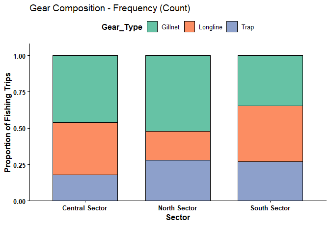

```r
p_bar_fill <- plot_bar(
  data         = fisheries_catch_survey,
  x            = "Sector",
  group        = "Gear_Type",
  position     = "fill",
  palette      = "Set2",
  ylab         = "Proportion of Fishing Trips",
  title_prefix = "Gear Composition"
)

p_bar_fill
```

#### 1.26.3.3 Style C: Horizontal Bar Chart for Station Inventories

When category labels are long, `horizontal = TRUE` flips coordinate axes to preserve legibility:

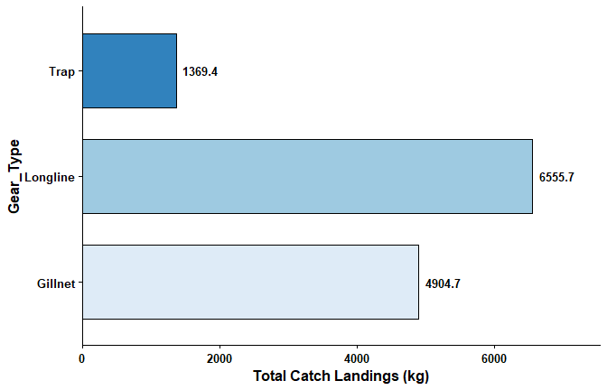

```r
p_bar_horiz <- plot_bar(
  data         = fisheries_catch_survey,
  x            = "Gear_Type",
  y            = "Landings_kg",
  stat         = "sum",
  horizontal   = TRUE,
  show_labels  = TRUE,
  palette      = "Blues",
  ylab         = "Total Catch Landings (kg)"
)

p_bar_horiz
```

#### 1.26.3.4 Style D: Clean Lollipop Plot for Total Catch Aggregations

Lollipop plots provide high contrast for ranked or discrete totals while eliminating visual clutter:

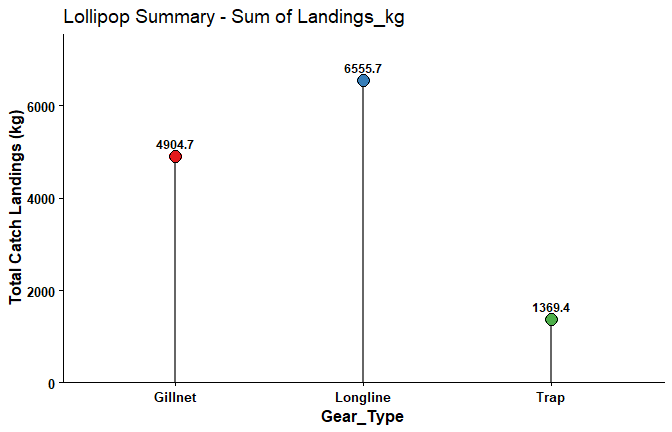

```r
p_lollipop <- plot_lollipop(
  data         = fisheries_catch_survey,
  x            = "Gear_Type",
  y            = "Landings_kg",
  stat         = "sum",
  point_size   = 4.0,
  line_size    = 1.0,
  show_labels  = TRUE,
  palette      = "Set1",
  ylab         = "Total Catch Landings (kg)",
  title_prefix = "Lollipop Summary"
)

p_lollipop
```

#### 1.26.3.5 Style E: Multi-Factor Dodged Lollipop Plot

Compares mean landings across gears dodged by coastal sector using lollipop geometry:

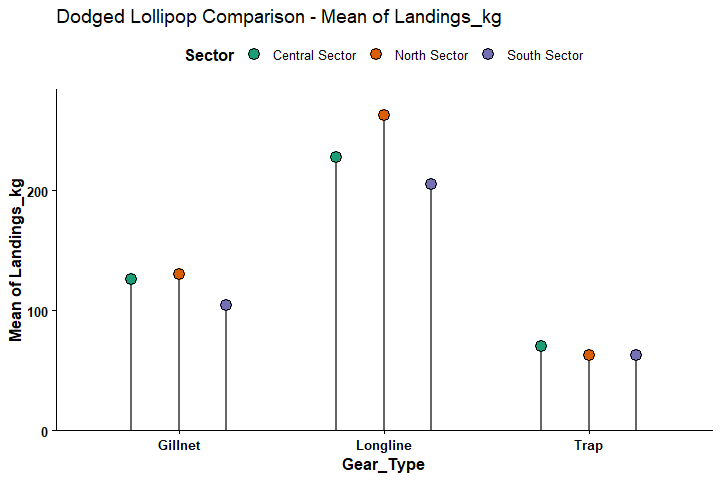

```r
p_lollipop_grouped <- plot_bar(
  data         = fisheries_catch_survey,
  x            = "Gear_Type",
  y            = "Landings_kg",
  group        = "Sector",
  type         = "lollipop",
  stat         = "mean",
  point_size   = 3.8,
  line_size    = 0.9,
  palette      = "Dark2",
  title_prefix = "Dodged Lollipop Comparison"
)

p_lollipop_grouped
```

### 1.26.4 Inspection of Aggregated Values

```r
# Summary table of Mean Landings per Gear and Sector
aggregate(Landings_kg ~ Gear_Type + Sector, data = fisheries_catch_survey, FUN = function(x) round(mean(x), 2))
```

```
#>   Gear_Type         Sector Landings_kg
#> 1   Gillnet Central Sector      126.12
#> 2  Longline Central Sector      227.89
#> 3      Trap Central Sector       70.24
#> 4   Gillnet   North Sector      130.36
#> 5  Longline   North Sector      262.84
#> 6      Trap   North Sector       62.66
#> 7   Gillnet   South Sector      104.42
#> 8  Longline   South Sector      205.10
#> 9      Trap   South Sector       62.73
```

## 1.27 Compositional Graphics & Survey Perception Analysis

In fisheries management, aquaculture surveys, and aquatic biomonitoring, reporting categorical proportions is standard practice. Whether portraying the percentage contribution of distinct species to total commercial landings, evaluating multi-tiered habitat classifications, or quantifying fisher community perceptions regarding marine protected areas (MPAs), standard plots often underperform in clarity or visual engagement.

The `aquats` package provides four specialized compositional and perception graphics: 1. `plot_pie3d()`: Native isometric 3D pie charts with perspective compression, extruded depth rims, and shadow rendering. 2. `plot_circular_bar()`: Radial bar charts with concentric reference gridlines and dynamic label angles for many-category comparisons. 3. `plot_donut()`: Single-, double-, or triple-tiered nested sunburst/donut charts representing hierarchical ecological structures. 4. `plot_likert()`: Diverging and 100% stacked horizontal bar charts designed for socio-economic survey evaluation.

### 1.27.1 3D Depth Pie Charts (`plot_pie3d`)

The `plot_pie3d()` function renders an isometric 3D pie chart directly in `ggplot2` by calculating geometric polygon coordinates for both the top circular face (compressed by perspective factor $\lambda \in [0.2, 0.8]$) and the extruded bottom rim:

$$x(\theta) = r \cos(\theta), \quad
y(\theta) = r \sin(\theta) \times \lambda$$

The front rim is extruded over the interval $\theta \in [\pi, 2\pi]$ (where $y \le 0$) with vertical depth $\delta$:

$$y_{\text{rim\_bottom}}(\theta) =
y(\theta) - \delta$$

We simulate commercial fisheries catch composition data across five key target species:

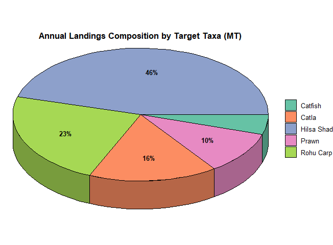

```r
catch_composition <- data.frame(
  Species     = c("Hilsa Shad", "Rohu Carp", "Catla", "Prawn", "Catfish"),
  Landings_MT = c(420, 210, 150, 95, 45)
)

p_pie <- plot_pie3d(
  data         = catch_composition,
  x            = "Species",
  y            = "Landings_MT",
  stat         = "identity",
  tilt         = 0.52,
  depth        = 0.22,
  show_labels  = TRUE,
  min_percent  = 5,
  palette      = "Set2",
  title        = "Annual Landings Composition by Target Taxa (MT)"
)

# Render 3D pie chart
p_pie
```

### 1.27.2 Circular Radial Bar Plots (`plot_circular_bar`)

When a categorical variable contains eight or more levels (e.g., river stations, fishing gears, sub-districts), standard vertical bar charts require horizontal label rotation that impairs readability. `plot_circular_bar()` maps values along a polar coordinate axis (`coord_polar`), reserving a central void fraction ($\rho$) and rendering dashed concentric reference rings with scale labels:

$$\theta_i = \frac{2\pi (i - 0.5)}{K},
\quad r_i = y_i$$

We simulate gear-specific catch per unit effort (CPUE in kg/haul) across 10 artisanal gear types:

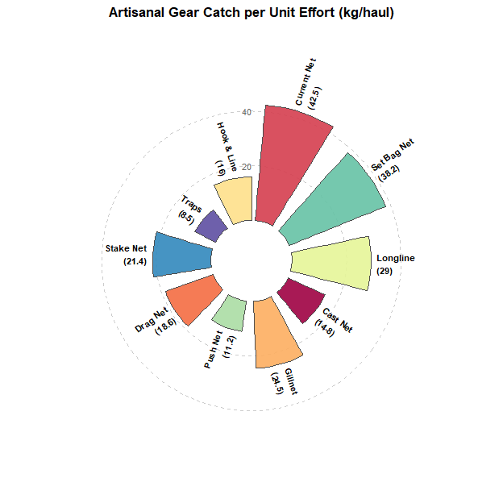

```r
gear_cpue <- data.frame(
  Gear = c("Current Net", "Set Bag Net", "Longline", "Cast Net", "Gillnet",
           "Push Net", "Drag Net", "Stake Net", "Traps", "Hook & Line"),
  CPUE = c(42.5, 38.2, 29.0, 14.8, 24.5, 11.2, 18.6, 21.4, 8.5, 16.0)
)

p_circular <- plot_circular_bar(
  data         = gear_cpue,
  x            = "Gear",
  y            = "CPUE",
  stat         = "identity",
  inner_radius = 0.35,
  show_grid    = TRUE,
  palette      = "Spectral",
  title        = "Artisanal Gear Catch per Unit Effort (kg/haul)"
)

# Render circular bar plot
p_circular
```

### 1.27.3 Hierarchical Nested Donut Charts (`plot_donut`)

The `plot_donut()` function displays hierarchical groupings (e.g., Habitat Zone $\to$ Feeding Guild $\to$ Target Species) across up to three concentric rings. Each layer aligns angular boundaries ($\theta_{\min}, \theta_{\max}$) with parent categories while varying radial boundaries ($r_{\text{in}}, r_{\text{out}}$):

$$\theta_{\text{start}}^{(k)} =
\sum_{j=1}^{k-1} p_j \times 2\pi, \quad \theta_{\text{end}}^{(k)} =
\sum_{j=1}^k p_j \times 2\pi$$

We simulate an estuarine survey categorizing fish biomass across Zone (Inner vs Outer Estuary) and Trophic Guild (Carnivore, Herbivore, Planktivore):

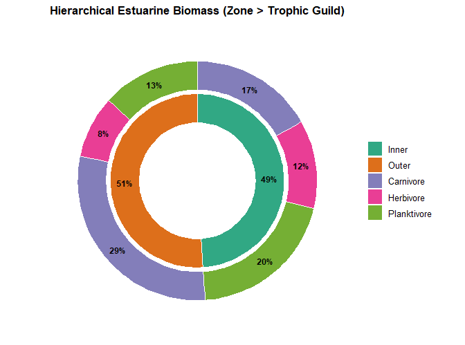

```r
hierarchical_survey <- data.frame(
  Zone    = c("Inner", "Inner", "Inner", "Outer", "Outer", "Outer"),
  Guild   = c("Carnivore", "Herbivore", "Planktivore", "Carnivore", "Herbivore", "Planktivore"),
  Biomass = c(120, 85, 145, 210, 60, 95)
)

p_donut <- plot_donut(
  data        = hierarchical_survey,
  levels      = c("Zone", "Guild"),
  value       = "Biomass",
  show_labels = TRUE,
  min_percent = 5,
  palette     = "Dark2",
  title       = "Hierarchical Estuarine Biomass (Zone > Trophic Guild)"
)

# Render nested donut chart
p_donut
```

### 1.27.4 Survey Perception Likert Visualizations (`plot_likert`)

Socio-economic evaluations in fisheries (e.g., fisher compliance, willingness to support seasonal bans, perception of catch declines) are recorded on ordinal Likert scales. `plot_likert()` aligns responses using either a diverging layout (centered on the neutral mid-point) or a 100% stacked layout.

For an odd number of categories $K$ with mid-point $M = \lceil K/2 \rceil$, the diverging coordinate offset is:

$$x_{\text{start}} = -\left(
\sum_{k=1}^{M-1} p_k + \frac{1}{2} p_M \right)$$

This splits the neutral category symmetrically across the vertical $x = 0$ axis while anchoring negative responses (Disagree) to the left and positive responses (Agree) to the right.

We simulate a community perception survey evaluating fisher responses across four socio-economic items:

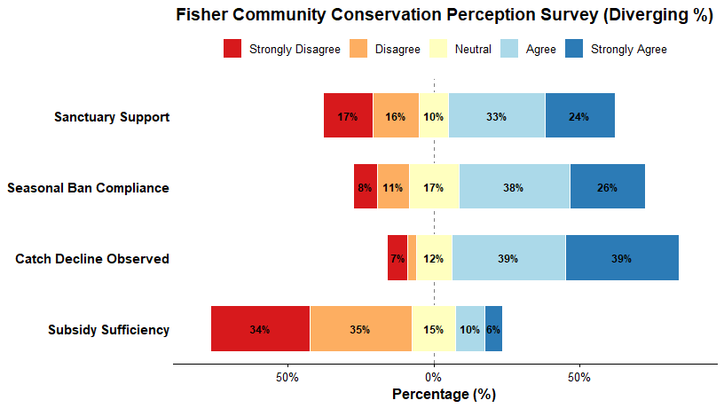

```r
set.seed(2525)
n_fishers <- 100

likert_levels <- c("Strongly Disagree", "Disagree", "Neutral", "Agree", "Strongly Agree")

survey_perceptions <- data.frame(
  Sanctuary_Support       = sample(likert_levels, n_fishers, replace = TRUE, prob = c(0.10, 0.15, 0.10, 0.35, 0.30)),
  Seasonal_Ban_Compliance = sample(likert_levels, n_fishers, replace = TRUE, prob = c(0.08, 0.12, 0.15, 0.40, 0.25)),
  Catch_Decline_Observed  = sample(likert_levels, n_fishers, replace = TRUE, prob = c(0.05, 0.08, 0.12, 0.35, 0.40)),
  Subsidy_Sufficiency     = sample(likert_levels, n_fishers, replace = TRUE, prob = c(0.35, 0.30, 0.15, 0.12, 0.08))
)

p_likert_diverging <- plot_likert(
  data         = survey_perceptions,
  items        = c("Sanctuary_Support", "Seasonal_Ban_Compliance", "Catch_Decline_Observed", "Subsidy_Sufficiency"),
  levels       = likert_levels,
  type         = "diverging",
  palette      = "RdYlBu",
  show_labels  = TRUE,
  clean_labels = TRUE,
  title        = "Fisher Community Conservation Perception Survey (Diverging %)"
)

# Render diverging Likert plot
p_likert_diverging
```

## 1.28 Ecological Flow and Trophic Visualizations (Sankey Diagram)

### 1.28.1 Conceptual Framework

Visualizing interconnected pathways—such as energy transfer across trophic webs, ontogenetic dietary shifts across life stages, contaminant routing through environmental compartments, or fish migration across river catchments—requires representing both categorical transitions and volumetric flow magnitudes.

Alluvial and Sankey diagrams represent discrete categories as vertically stacked blocks (**strata**) distributed across consecutive parallel stages (**axes**), interconnected by curvilinear ribbons (**alluvia**) whose heights are proportional to flow frequency, biomass, or energy flux. The `plot_sankey()` function provides a publication-ready interface built on top of `ggalluvial` and `ggplot2`, offering automated frequency aggregation, weighted flows, missing-case filtering, and adaptive color palette interpolation.

### 1.28.2 Flow Allocation and Stratum Architecture

The diagram decomposes relational data across $k$ ordered categorical axes: 1. **Strata (Nodes):** Represent discrete factor levels $A_{i, j}$ at stage $i$. 2. **Alluvia (Flow Ribbons):** Trace the path taken by observations across all stages $i \in \{1, \ldots, k\}$. 3. **Weighting Metrics:** * **Unweighted Frequency ($N$):** When `value = NULL`, ribbon thickness represents sample counts:
$$W = \sum 1$$
* **Weighted Flux ($V$):** When `value` is assigned (e.g., ingested biomass $\text{g}$, energy flow $\text{t}\cdot\text{km}^{-2}\cdot\text{year}^{-1}$, or contaminant concentration), ribbon thickness scales to cumulative quantity:
$$W = \sum V$$

### 1.28.3 In-Vignette Data Generation

We simulate an aquatic dietary study evaluating stomach content analysis across life stages, predatory feeding guilds, and preferred prey taxa:

```r
set.seed(42)
diet_survey <- data.frame(
  Life_Stage    = factor(
    sample(c("Juvenile", "Sub-Adult", "Adult"), 200, replace = TRUE, prob = c(0.40, 0.35, 0.25)),
    levels = c("Juvenile", "Sub-Adult", "Adult")
  ),
  Feeding_Guild = factor(
    sample(c("Planktivore", "Benthivore", "Piscivore"), 200, replace = TRUE, prob = c(0.45, 0.35, 0.20)),
    levels = c("Planktivore", "Benthivore", "Piscivore")
  ),
  Prey_Taxa     = factor(
    sample(c("Cladocera", "Chironomidae", "Small Teleost", "Detritus"), 200, replace = TRUE),
    levels = c("Cladocera", "Chironomidae", "Small Teleost", "Detritus")
  ),
  Biomass_g     = round(runif(200, min = 0.5, max = 18.5), 2)
)

head(diet_survey)
```

```
#>   Life_Stage Feeding_Guild    Prey_Taxa Biomass_g
#> 1      Adult     Piscivore     Detritus      9.47
#> 2      Adult    Benthivore     Detritus      5.59
#> 3   Juvenile     Piscivore     Detritus     14.48
#> 4      Adult   Planktivore    Cladocera      5.97
#> 5  Sub-Adult   Planktivore     Detritus      9.78
#> 6  Sub-Adult   Planktivore Chironomidae      9.10
```

### 1.28.4 Visualization Styles

#### 1.28.4.1 Style A: Biomass-Weighted Multi-Tier Alluvial

Flow ribbons are scaled to total prey biomass ($\text{g}$) and colored according to the primary origin axis (`Life_Stage`):

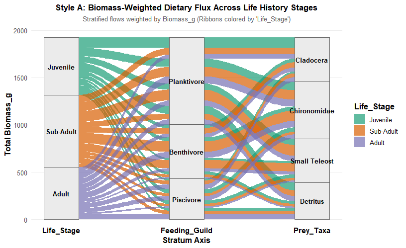

```r
p_weighted <- plot_sankey(
  data         = diet_survey,
  axes         = c("Life_Stage", "Feeding_Guild", "Prey_Taxa"),
  value        = "Biomass_g",
  fill_axis    = "Life_Stage",
  alpha        = 0.70,
  width        = 0.28,
  palette      = "Dark2",
  title        = "Style A: Biomass-Weighted Dietary Flux Across Life History Stages"
)

print(p_weighted)
```

#### 1.28.4.2 Style B: Unweighted Observation Frequency (Count Flow)

When individual sample records or capture occurrences are tracked without biomass weighting (`value = NULL`), ribbons reflect observation frequencies and are colored by the intermediate axis (`Feeding_Guild`):

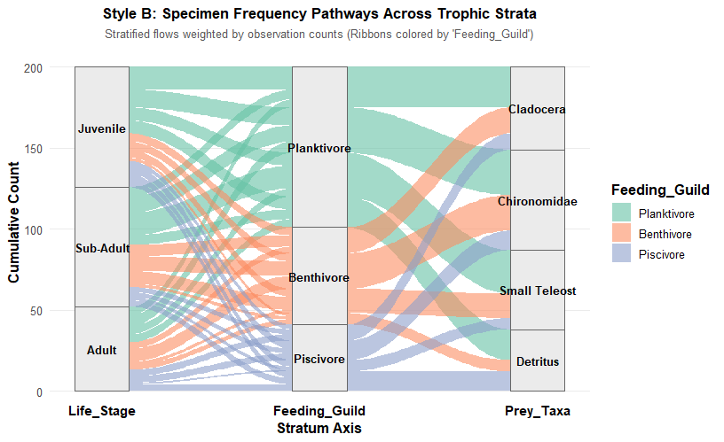

```r
p_counts <- plot_sankey(
  data         = diet_survey,
  axes         = c("Life_Stage", "Feeding_Guild", "Prey_Taxa"),
  value        = NULL,             # Automatically computes record counts
  fill_axis    = "Feeding_Guild",  # Colors ribbons by guild category
  alpha        = 0.60,
  palette      = "Set2",
  title        = "Style B: Specimen Frequency Pathways Across Trophic Strata"
)

print(p_counts)
```

#### 1.28.4.3 Style C: Two-Tier Catchment-to-Estuary Transition

Sankey diagrams can also model spatial routing or migration between two distinct environmental zones:

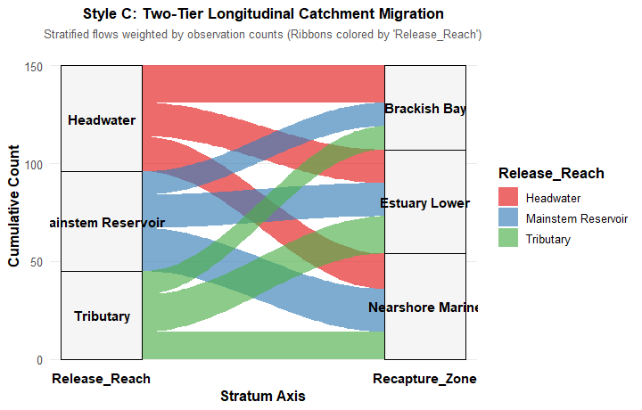

```r
# Simulate upstream-to-downstream fish passage counts
set.seed(101)
passage_data <- data.frame(
  Release_Reach = sample(c("Headwater", "Mainstem Reservoir", "Tributary"), 150, replace = TRUE),
  Recapture_Zone = sample(c("Estuary Lower", "Brackish Bay", "Nearshore Marine"), 150, replace = TRUE)
)

p_passage <- plot_sankey(
  data          = passage_data,
  axes          = c("Release_Reach", "Recapture_Zone"),
  fill_axis     = 1,
  stratum_fill  = "grey96",
  stratum_color = "black",
  label_size    = 4.0,
  palette       = "Set1",
  title         = "Style C: Two-Tier Longitudinal Catchment Migration"
)

print(p_passage)
```

### 1.28.5 Customizing and Exporting Diagrams

Because `plot_sankey()` returns a native `ggplot2` object, it integrates with standard `ggplot2` layers and themes:

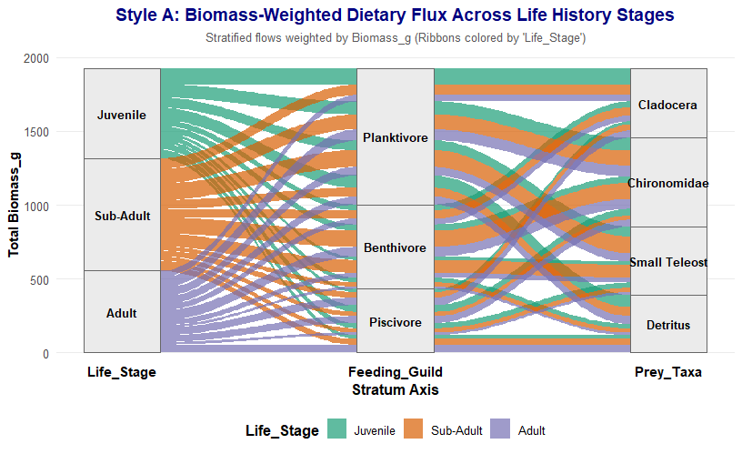

```r
# Add custom axis adjustments and styling layers
p_custom <- p_weighted +
  ggplot2::theme(
    legend.position = "bottom",
    plot.title      = ggplot2::element_text(color = "navy", face = "bold", size = 14),
    axis.title.y    = ggplot2::element_text(size = 11, face = "bold")
  ) +
  ggplot2::guides(fill = ggplot2::guide_legend(nrow = 1))

print(p_custom)
```

To export the diagram at publication resolution:

```r
ggplot2::ggsave(
  filename = "trophic_sankey_diagram.png",
  plot     = p_custom,
  width    = 9,
  height   = 5.5,
  dpi      = 300
)
```

## 1.29 Temporal Tracking & Multi-Factor Time-Series Analysis

The `plot_timeseries()` function provides publication-grade line tracking and longitudinal time-series visualization for limnological water chemistry, estuarine hydrology, and fisheries stock surveys. In long-term aquatic studies, monitoring parameters across temporal gradients (e.g., daily tidal cycles, monthly flood pulses, annual recruitment oscillations) requires clear visualization of trends while accounting for within-season sampling error.

The function handles: 1. Diverse Time-Step Ingestion: Parses date formats (`Date`, `POSIXct`), continuous numeric steps (e.g., Year: 2018–2026), or ordered calendar factors (`"Jan"`, `"Feb"`, `"Mar"` or seasonal pulses: `"Pre-Monsoon"`, `"Monsoon"`, `"Post-Monsoon"`). 2. Multi-Factor Hierarchical Partitioning: - Single-Factor: Unstratified ecosystem temporal tracking. - Two-Factor: Multi-station or inter-species trajectories differentiated by color (`color_var`). - Three-Factor (Factorial Interaction): High-dimensional tracking combining color, line styles (`linetype_var`), and multi-panel faceting (`facet_var`). 3. Automated Replicate Aggregation: Automatically averages replicate samples per time-step and constructs shaded uncertainty bands: 95% Confidence Intervals (`"ci"`), Standard Error (`"se"`), or Standard Deviation (`"sd"`).

### 1.29.1 Conceptual Framework & Uncertainty Band Mechanics

Let $y_{t, i}$ denote the $i$-th sample replicate ($i = 1, \dots, n_t$) observed at temporal interval $t$.

#### 1.29.1.1 Replicate Arithmetic Mean

$$\bar{y}_t = \frac{1}{n_t}
\sum_{i=1}^{n_t} y_{t, i}$$

#### 1.29.1.2 Standard Error of the Mean (SE Ribbon)

Quantifies the precision of the estimated mean trajectory across repeated sampling visits:
$$\text{SE}_t =
\frac{s_t}{\sqrt{n_t}}, \quad \text{Ribbon}_{\text{SE}} = \bar{y}_t \pm
\text{SE}_t$$

#### 1.29.1.3 95% Student’s $t$ Confidence Band (CI Ribbon)

Constructs the confidence boundary containing the true population parameter $\mu_t$ at level $\alpha = 0.05$:
$$\text{CI}_{95\%, \, t} = \bar{y}_t \pm t_{n_t -
1, \, 0.975} \times \frac{s_t}{\sqrt{n_t}}$$

### 1.29.2 In-Vignette Data Generation

We simulate a 12-month estuarine monitoring survey tracking Dissolved Oxygen (mg/L) across three River Stations (`Upper River`, `Middle Basin`, `Estuary Mouth`) at two distinct Water Depths (`Surface` vs. `Bottom`), collecting 4 replicate water column grabs per visit:

```r
set.seed(2929)
months_seq <- c("Jan", "Feb", "Mar", "Apr", "May", "Jun", "Jul", "Aug", "Sep", "Oct", "Nov", "Dec")
stations   <- c("Upper River", "Middle Basin", "Estuary Mouth")
depths     <- c("Surface", "Bottom")
n_reps     <- 4

ts_grid <- expand.grid(Month = months_seq, Station = stations, Depth = depths)

ts_rows <- lapply(seq_len(nrow(ts_grid)), function(i) {
  m  <- as.character(ts_grid$Month[i])
  st <- as.character(ts_grid$Station[i])
  dp <- as.character(ts_grid$Depth[i])

  # Base seasonal oxygen curve (higher in winter, lower during summer stratification)
  m_idx <- match(m, months_seq)
  base_do <- 7.5 + 2.2 * cos((m_idx - 1) * (2 * pi / 12))

  # Spatial and depth adjustments
  st_offset <- switch(st, "Upper River" = 0.8, "Middle Basin" = 0.0, "Estuary Mouth" = -0.6)
  dp_offset <- if (dp == "Bottom") -1.4 else 0.0

  sim_do <- pmax(2.0, rnorm(n_reps, mean = base_do + st_offset + dp_offset, sd = 0.35))

  data.frame(
    Month   = factor(m, levels = months_seq),
    Station = st,
    Depth   = dp,
    DO_mgL  = round(sim_do, 2),
    stringsAsFactors = FALSE
  )
})

aquatic_timeseries <- do.call(rbind, ts_rows)
head(aquatic_timeseries, 8)
```

```
#>   Month     Station   Depth DO_mgL
#> 1   Jan Upper River Surface  10.63
#> 2   Jan Upper River Surface  10.49
#> 3   Jan Upper River Surface  10.59
#> 4   Jan Upper River Surface  10.39
#> 5   Feb Upper River Surface   9.88
#> 6   Feb Upper River Surface   9.65
#> 7   Feb Upper River Surface   9.64
#> 8   Feb Upper River Surface  10.59
```

### 1.29.3 Visualization Styles

`plot_timeseries()` provides single-series trajectories, multi-line comparisons, and full three-factor factorial faceted layouts.

#### 1.29.3.1 Style A: Single-Series Temporal Trajectory with 95% CI Ribbon (Default)

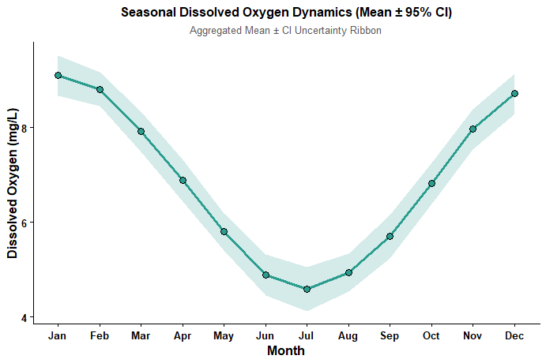

```r
res_ts_single <- plot_timeseries(
  data       = aquatic_timeseries,
  time_var   = "Month",
  y_var      = "DO_mgL",
  ribbon     = "ci",
  point_size = 2.8,
  line_width = 1.1,
  ylab       = "Dissolved Oxygen (mg/L)",
  title      = "Seasonal Dissolved Oxygen Dynamics (Mean \u00b1 95% CI)"
)

# Render single-series plot
res_ts_single$Plot
```

#### 1.29.3.2 Style B: Two-Factor Comparison with Color-Coded Stations & SE Ribbons

Compares monthly trajectories across three river monitoring stations using color-coded lines and Standard Error ($\pm 1\text{ SE}$) ribbons:

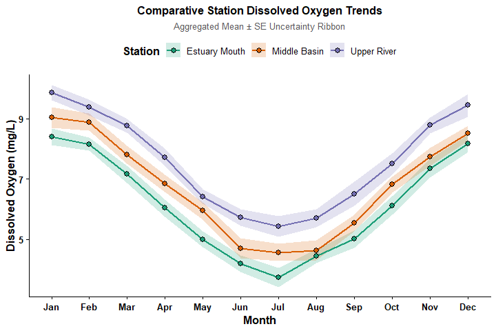

```r
res_ts_stations <- plot_timeseries(
  data          = aquatic_timeseries,
  time_var      = "Month",
  y_var         = "DO_mgL",
  color_var     = "Station",
  ribbon        = "se",
  color_palette = "Dark2",
  point_size    = 2.4,
  line_width    = 1.0,
  ylab          = "Dissolved Oxygen (mg/L)",
  title         = "Comparative Station Dissolved Oxygen Trends"
)

res_ts_stations$Plot
```

#### 1.29.3.3 Style C: Three-Factor Factorial Layout (Color + Linetype + Facet)

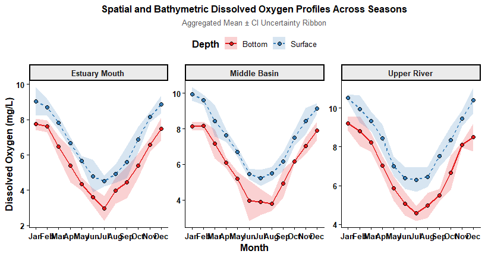

```r
res_ts_factorial <- plot_timeseries(
  data          = aquatic_timeseries,
  time_var      = "Month",
  y_var         = "DO_mgL",
  color_var     = "Depth",
  linetype_var  = "Depth",
  facet_var     = "Station",
  ribbon        = "ci",
  color_palette = "Set1",
  point_size    = 2.2,
  ylab          = "Dissolved Oxygen (mg/L)",
  title         = "Spatial and Bathymetric Dissolved Oxygen Profiles Across Seasons"
)

res_ts_factorial$Plot
```

### 1.29.4 Summary Table Inspection

The returned list contains the aggregated statistical table, detailing replicate counts ($N$), Means, Standard Deviations, Standard Errors, and Confidence Limits for each discrete temporal coordinate:

```r
# 1. Preview aggregated summary statistics table (First 6 records)
head(res_ts_factorial$Summary_Data, 6)
```

```
#>   Month  Depth Depth.1       Station N   Mean        SD         SE      LCI
#> 1   Jan Bottom  Bottom Estuary Mouth 4 7.7525 0.1992277 0.09961384 7.435484
#> 2   Feb Bottom  Bottom Estuary Mouth 4 7.6200 0.2141650 0.10708252 7.279216
#> 3   Mar Bottom  Bottom Estuary Mouth 4 6.4825 0.3854327 0.19271633 5.869191
#> 4   Apr Bottom  Bottom Estuary Mouth 4 5.4100 0.6069596 0.30347982 4.444192
#> 5   May Bottom  Bottom Estuary Mouth 4 4.3450 0.2272297 0.11361485 3.983427
#> 6   Jun Bottom  Bottom Estuary Mouth 4 3.6150 0.3055596 0.15277980 3.128786
#>        UCI
#> 1 8.069516
#> 2 7.960784
#> 3 7.095809
#> 4 6.375808
#> 5 4.706573
#> 6 4.101214
```

# Conclusion

The `aquats` package bridges rigorous statistical modeling, ecological ordination, and publication-ready visualization into a unified, reproducible framework tailored for observe data in experimental studies, aquatic ecology, and fisheries science. By integrating standard hypothesis tests, generalized linear models, multi-metric water quality indices, multivariate community dynamics, and longitudinal time-series tracking, `aquats` streamlines complex analytical workflows from raw survey matrices to finalized decision metrics. Users are empowered to conduct transparent, robust evaluations that support evidence-based management and conservation of aquatic ecosystems.

# Acknowledgements

I would like to express my heartfelt gratitude and sincere respect to my supervisor, **Dr. Mohammed Shahidul Alam**, Associate Professor, Department of Fisheries, University of Chittagong, for his invaluable guidance, continuous encouragement, and scholarly support throughout the conceptualization and development of this package.

I also extend my sincere appreciation to the open-source R development community, the members of the aquatic ecology research, and all peer reviewers whose constructive feedback and testing helped refine the package’s numerical routines and visualization standards.

# References

- **Anderson, M. J. (2001).** A new method for non-parametric multivariate analysis of variance. *Austral Ecology*, 26(1), 32–46. https://doi.org/10.1111/j.1442-9993.2001.01070.pp.x
- **Brown, R. M., McClelland, N. I., Deininger, R. A., & Tozer, R. G. (1970).** A water quality index—do we dare? *Water & Sewage Works*, 117(10), 339–343.
- **Clarke, K. R. (1993).** Non-parametric multivariate analyses of changes in community structure. *Australian Journal of Ecology*, 18(1), 117–143. https://doi.org/10.1111/j.1442-9993.1993.tb00438.x
- **Coleman, B. D., Mares, M. A., Willig, M. R., & Hsieh, Y.-H. (1982).** Randomness, area, and species richness. *Ecology*, 63(4), 1121–1133. https://doi.org/10.2307/1937249
- **Gotelli, N. J., & Colwell, R. K. (2001).** Quantifying biodiversity: procedures and pitfalls in the measurement and comparison of species-richness. *Ecology Letters*, 4(4), 379–391. https://doi.org/10.1046/j.1461-0248.2001.00230.x
- **Hakanson, L. (1980).** An ecological risk index for aquatic pollution control: A sedimentological approach. *Water Research*, 14(8), 975–1001. https://doi.org/10.1016/0043-1354(80)90143-8
- **Kruskal, J. B. (1964).** Multidimensional scaling by optimizing goodness of fit to a nonmetric hypothesis. *Psychometrika*, 29(1), 1–27. https://doi.org/10.1007/BF02289565
- **Legendre, P., & Anderson, M. J. (1999).** Distance-based redundancy analysis: Testing multispecies responses in multifactorial ecological experiments. *Ecological Monographs*, 69(1), 1–24. https://doi.org/10.1890/0012-9615(1999)069[0001:DBRATM]2.0.CO;2
- **Legendre, P., & Gallagher, E. D. (2001).** Ecologically meaningful transformations for ordination of species data. *Oecologia*, 129(2), 271–280. https://doi.org/10.1007/s004420100716
- **Legendre, P., & Legendre, L. (2012).** *Numerical Ecology* (3rd English ed.). Elsevier Science. ISBN: 978-0-444-53868-0.
- **Mantel, N. (1967).** The detection of disease clustering and a generalized regression approach. *Cancer Research*, 27(2), 209–220.
- **Margalef, R. (1958).** Information theory in ecology. *General Systems*, 3, 36–71.
- **McCullagh, P., & Nelder, J. A. (1989).** *Generalized Linear Models* (2nd ed.). Chapman & Hall/CRC. ISBN: 978-0-412-31760-6.
- **Oksanen, J., Simpson, G. L., Blanchet, F. G., Kindt, R., Legendre, P., Minchin, P. R., O’Hara, R. B., et al. (2022).** *vegan: Community Ecology Package*. R package version 2.6-4. https://CRAN.R-project.org/package=vegan
- **Pielou, E. C. (1966).** The measurement of diversity in different types of biological collections. *Journal of Theoretical Biology*, 13, 131–144. https://doi.org/10.1016/0022-5193(66)90013-0
- **Pillai, K. C. S. (1955).** Some new test criteria in multivariate analysis. *The Annals of Mathematical Statistics*, 26(1), 117–121. https://doi.org/10.1214/aoms/1177728607
- **Shannon, C. E. (1948).** A mathematical theory of communication. *Bell System Technical Journal*, 27(3), 379–423. https://doi.org/10.1002/j.1538-7305.1948.tb01338.x
- **Simpson, E. H. (1949).** Measurement of diversity. *Nature*, 163(4148), 688. https://doi.org/10.1038/163688a0
- **Tomlinson, D. L., Wilson, J. G., Harris, C. R., & Jeffrey, D. W. (1980).** Problems in the assessment of heavy-metal levels in estuaries and the formation of a pollution index. *Helgoländer Meeresuntersuchungen*, 33(1), 566–575. https://doi.org/10.1007/BF02414780
- **Ward, J. H. (1963).** Hierarchical grouping to optimize an objective function. *Journal of the American Statistical Association*, 58(301), 236–244. https://doi.org/10.1080/01621459.1963.10500845
- **Wickham, H. (2016).** *ggplot2: Elegant Graphics for Data Analysis*. Springer-Verlag New York. https://doi.org/10.1007/978-3-319-24277-4

# Additional Information & Bug Reporting

If you encounter unexpected errors, package bugs, or would like to request new ecological functions or visualization styles, please submit an issue report on GitHub or contact the author directly.

- **Author & Maintainer:** Ataher Ali
- **Affiliation:** Department of Fisheries, Faculty of Marine Science & Fisheries, University of Chittagong, Chattogram 4331, Bangladesh
- **Email:** ataher.cu.ms@gmail.com
- **Bug Reports:** https://github.com/Ataher76/aquats/issues

To cite the `aquats` package in scholarly articles, reports, or research presentations, please use:

> Ali, A., & Alam, M. S. (2026). *aquats: Robust Ecological and Fisheries Data Analysis and Visualization* (v1.2.1). Zenodo. https://doi.org/10.5281/zenodo.22885025

You can also generate the BibTeX entry directly in R:

```r
citation("aquats")
```

```
@Manual{,
  title  = {aquats: Robust Ecological and Fisheries Data Analysis and Visualization},
  author = {Ataher Ali and Mohammed Shahidul Alam},
  year   = {2026},
  note   = {R package version 1.2.1},
  doi    = {10.5281/zenodo.22885025},
  url    = {https://github.com/Ataher76/aquats}
}
```